# NCDB Pituitary Carcinoma 2015

All

Jason Brant

June 21, 2018

**Note: To hide the code from this document, click the button in the upper right corner.**

```r
col.width <- c(37, 10, 1, 1, 3, 1, 2, 1, 2, 1, 1, 1, 1, 1, 1, 8, 2, 2, 2, 4, 4, 1, 4, 1, 1, 1, 3, 2, 2, 8,
               2, 5, 5, 5, 4, 5, 5, 5, 4, 2, 1, 2, 1, 3, 1, 1, 1, 1, 1, 1, 3, 3, 3, 3, 3, 3, 3, 3, 3, 3, 3,
               3, 3, 3, 3, 3, 3, 3, 3, 3, 3, 3, 3, 3, 3, 6, 8, 8, 8, 2, 1, 1, 1, 1, 8, 1, 1, 8, 1, 1, 2,
               2, 5, 2, 5, 3, 1, 3, 1, 8, 8, 2, 8, 2, 8, 2, 2, 1, 8, 1, 1, 1, 1, 1, 8, 1, 2, 2, 2, 2, 2,
               1, 1, 1, 2, 1)
col.names.abr <- c("PUF_CASE_ID", "PUF_FACILITY_ID", "FACILITY_TYPE_CD",  "FACILITY_LOCATION_CD", "AGE", "SEX", "RACE",
                   "SPANISH_HISPANIC_ORIGIN", "INSURANCE_STATUS", "MED_INC_QUAR_00", "NO_HSD_QUAR_00", "UR_CD_03",
                   "MED_INC_QUAR_12", "NO_HSD_QUAR_12", "UR_CD_13", "CROWFLY", "CDCC_TOTAL", "SEQUENCE_NUMBER",
                   "CLASS_OF_CASE", "YEAR_OF_DIAGNOSIS", "PRIMARY_SITE",  "LATERALITY", "HISTOLOGY", "BEHAVIOR",
                   "GRADE", "DIAGNOSTIC_CONFIRMATION", "TUMOR_SIZE", "REGIONAL_NODES_POSITIVE",
                   "REGIONAL_NODES_EXAMINED", "DX_STAGING_PROC_DAYS", "RX_SUMM_DXSTG_PROC", "TNM_CLIN_T",
                   "TNM_CLIN_N", "TNM_CLIN_M", "TNM_CLIN_STAGE_GROUP", "TNM_PATH_T", "TNM_PATH_N", "TNM_PATH_M",
                   "TNM_PATH_STAGE_GROUP", "TNM_EDITION_NUMBER", "ANALYTIC_STAGE_GROUP", "CS_METS_AT_DX",
                   "CS_METS_EVAL", "CS_EXTENSION", "CS_TUMOR_SIZEEXT_EVAL", "CS_METS_DX_BONE",
                   "CS_METS_DX_BRAIN", "CS_METS_DX_LIVER", "CS_METS_DX_LUNG", "LYMPH_VASCULAR_INVASION",
                   "CS_SITESPECIFIC_FACTOR_1", "CS_SITESPECIFIC_FACTOR_2", "CS_SITESPECIFIC_FACTOR_3",
                   "CS_SITESPECIFIC_FACTOR_4", "CS_SITESPECIFIC_FACTOR_5", "CS_SITESPECIFIC_FACTOR_6",
                   "CS_SITESPECIFIC_FACTOR_7", "CS_SITESPECIFIC_FACTOR_8", "CS_SITESPECIFIC_FACTOR_9",
                   "CS_SITESPECIFIC_FACTOR_10", "CS_SITESPECIFIC_FACTOR_11", "CS_SITESPECIFIC_FACTOR_12",
                   "CS_SITESPECIFIC_FACTOR_13", "CS_SITESPECIFIC_FACTOR_14", "CS_SITESPECIFIC_FACTOR_15",
                   "CS_SITESPECIFIC_FACTOR_16", "CS_SITESPECIFIC_FACTOR_17", "CS_SITESPECIFIC_FACTOR_18",
                   "CS_SITESPECIFIC_FACTOR_19", "CS_SITESPECIFIC_FACTOR_20", "CS_SITESPECIFIC_FACTOR_21",
                   "CS_SITESPECIFIC_FACTOR_22", "CS_SITESPECIFIC_FACTOR_23", "CS_SITESPECIFIC_FACTOR_24",
                   "CS_SITESPECIFIC_FACTOR_25", "CS_VERSION_LATEST", "DX_RX_STARTED_DAYS",
                   "DX_SURG_STARTED_DAYS", "DX_DEFSURG_STARTED_DAYS", "RX_SUMM_SURG_PRIM_SITE",
                   "RX_HOSP_SURG_APPR_2010", "RX_SUMM_SURGICAL_MARGINS", "RX_SUMM_SCOPE_REG_LN_SUR",
                   "RX_SUMM_SURG_OTH_REGDIS", "SURG_DISCHARGE_DAYS", "READM_HOSP_30_DAYS",
                   "REASON_FOR_NO_SURGERY", "DX_RAD_STARTED_DAYS", "RX_SUMM_RADIATION", "RAD_LOCATION_OF_RX",
                   "RAD_TREAT_VOL", "RAD_REGIONAL_RX_MODALITY", "RAD_REGIONAL_DOSE_CGY",
                   "RAD_BOOST_RX_MODALITY", "RAD_BOOST_DOSE_CGY", "RAD_NUM_TREAT_VOL",
                   "RX_SUMM_SURGRAD_SEQ", "RAD_ELAPSED_RX_DAYS", "REASON_FOR_NO_RADIATION",
                   "DX_SYSTEMIC_STARTED_DAYS", "DX_CHEMO_STARTED_DAYS", "RX_SUMM_CHEMO",
                   "DX_HORMONE_STARTED_DAYS", "RX_SUMM_HORMONE", "DX_IMMUNO_STARTED_DAYS",
                   "RX_SUMM_IMMUNOTHERAPY", "RX_SUMM_TRNSPLNT_ENDO", "RX_SUMM_SYSTEMIC_SUR_SEQ",
                   "DX_OTHER_STARTED_DAYS", "RX_SUMM_OTHER", "PALLIATIVE_CARE", "RX_SUMM_TREATMENT_STATUS",
                   "PUF_30_DAY_MORT_CD", "PUF_90_DAY_MORT_CD", "DX_LASTCONTACT_DEATH_MONTHS",
                   "PUF_VITAL_STATUS", "RX_HOSP_SURG_PRIM_SITE", "RX_HOSP_CHEMO", "RX_HOSP_IMMUNOTHERAPY",
                   "RX_HOSP_HORMONE", "RX_HOSP_OTHER", "PUF_MULT_SOURCE", "REFERENCE_DATE_FLAG",
                   "RX_SUMM_SCOPE_REG_LN_2012", "RX_HOSP_DXSTG_PROC", "PALLIATIVE_CARE_HOSP")
#Read in data for each subsite
bone.joint <- read_fwf('I:/Brant/Research/NCDB/Data/Data_2017/NCDB_PUF_DATA_Nov-07-2017/NCDBPUF_BoneJont.3.2015.0.dat',
                       fwf_widths(col.width, col_names = col.names.abr),
                       col_types = cols(.default = col_character()))
brain <- read_fwf('I:/Brant/Research/NCDB/Data/Data_2017/NCDB_PUF_DATA_Nov-07-2017/NCDBPUF_Brain.3.2015.0.dat',
                       fwf_widths(col.width, col_names = col.names.abr),
                       col_types = cols(.default = col_character()))
cns <- read_fwf('I:/Brant/Research/NCDB/Data/Data_2017/NCDB_PUF_DATA_Nov-07-2017/NCDBPUF_CNS.3.2015.0.dat',
                       fwf_widths(col.width, col_names = col.names.abr),
                       col_types = cols(.default = col_character()))
gum.ot.mth <- read_fwf('I:/Brant/Research/NCDB/Data/Data_2017/NCDB_PUF_DATA_Nov-07-2017/NCDBPUF_GumOtMth.3.2015.0.dat',
                       fwf_widths(col.width, col_names = col.names.abr),
                       col_types = cols(.default = col_character()))
hypophar <- read_fwf('I:/Brant/Research/NCDB/Data/Data_2017/NCDB_PUF_DATA_Nov-07-2017/NCDBPUF_Hypophar.3.2015.0.dat',
                       fwf_widths(col.width, col_names = col.names.abr),
                       col_types = cols(.default = col_character()))
larynx <- read_fwf('I:/Brant/Research/NCDB/Data/Data_2017/NCDB_PUF_DATA_Nov-07-2017/NCDBPUF_Larynx.3.2015.0.dat',
                       fwf_widths(col.width, col_names = col.names.abr),
                       col_types = cols(.default = col_character()))
lip <- read_fwf('I:/Brant/Research/NCDB/Data/Data_2017/NCDB_PUF_DATA_Nov-07-2017/NCDBPUF_Lip.3.2015.0.dat',
                       fwf_widths(col.width, col_names = col.names.abr),
                       col_types = cols(.default = col_character()))
melanoma <- read_fwf('I:/Brant/Research/NCDB/Data/Data_2017/NCDB_PUF_DATA_Nov-07-2017/NCDBPUF_Melanoma.3.2015.0.dat',
                       fwf_widths(col.width, col_names = col.names.abr),
                       col_types = cols(.default = col_character()))
fom <- read_fwf('I:/Brant/Research/NCDB/Data/Data_2017/NCDB_PUF_DATA_Nov-07-2017/NCDBPUF_MouthFlr.3.2015.0.dat',
                       fwf_widths(col.width, col_names = col.names.abr),
                       col_types = cols(.default = col_character()))
nasal <- read_fwf('I:/Brant/Research/NCDB/Data/Data_2017/NCDB_PUF_DATA_Nov-07-2017/NCDBPUF_Nasal.3.2015.0.dat',
                       fwf_widths(col.width, col_names = col.names.abr),
                       col_types = cols(.default = col_character()))
nasophar <- read_fwf('I:/Brant/Research/NCDB/Data/Data_2017/NCDB_PUF_DATA_Nov-07-2017/NCDBPUF_Nasophar.3.2015.0.dat',
                       fwf_widths(col.width, col_names = col.names.abr),
                       col_types = cols(.default = col_character()))
orophar <- read_fwf('I:/Brant/Research/NCDB/Data/Data_2017/NCDB_PUF_DATA_Nov-07-2017/NCDBPUF_Orophary.3.2015.0.dat',
                       fwf_widths(col.width, col_names = col.names.abr),
                       col_types = cols(.default = col_character()))
oth.endo <- read_fwf('I:/Brant/Research/NCDB/Data/Data_2017/NCDB_PUF_DATA_Nov-07-2017/NCDBPUF_OtEndocr.3.2015.0.dat',
                       fwf_widths(col.width, col_names = col.names.abr),
                       col_types = cols(.default = col_character()))
skin <- read_fwf('I:/Brant/Research/NCDB/Data/Data_2017/NCDB_PUF_DATA_Nov-07-2017/NCDBPUF_OtSkin.3.2015.0.dat',
                       fwf_widths(col.width, col_names = col.names.abr),
                       col_types = cols(.default = col_character()))
pharynx <- read_fwf('I:/Brant/Research/NCDB/Data/Data_2017/NCDB_PUF_DATA_Nov-07-2017/NCDBPUF_Pharynx.3.2015.0.dat',
                       fwf_widths(col.width, col_names = col.names.abr),
                       col_types = cols(.default = col_character()))
saliv.gland <- read_fwf('I:/Brant/Research/NCDB/Data/Data_2017/NCDB_PUF_DATA_Nov-07-2017/NCDBPUF_SalivGld.3.2015.0.dat',
                       fwf_widths(col.width, col_names = col.names.abr),
                       col_types = cols(.default = col_character()))
thyroid <- read_fwf('I:/Brant/Research/NCDB/Data/Data_2017/NCDB_PUF_DATA_Nov-07-2017/NCDBPUF_Thyroid.3.2015.0.dat',
                       fwf_widths(col.width, col_names = col.names.abr),
                       col_types = cols(.default = col_character()))
tongue <- read_fwf('I:/Brant/Research/NCDB/Data/Data_2017/NCDB_PUF_DATA_Nov-07-2017/NCDBPUF_Tongue.3.2015.0.dat',
                       fwf_widths(col.width, col_names = col.names.abr),
                       col_types = cols(.default = col_character()))
tonsil <- read_fwf('I:/Brant/Research/NCDB/Data/Data_2017/NCDB_PUF_DATA_Nov-07-2017/NCDBPUF_Tonsil.3.2015.0.dat',
                       fwf_widths(col.width, col_names = col.names.abr),
                       col_types = cols(.default = col_character()))
trach.med <- read_fwf('I:/Brant/Research/NCDB/Data/Data_2017/NCDB_PUF_DATA_Nov-07-2017/NCDBPUF_TrachMed.3.2015.0.dat',
                       fwf_widths(col.width, col_names = col.names.abr),
                       col_types = cols(.default = col_character()))
#Combine data for all subsites
dat <- bind_rows(bone.joint, brain, cns, gum.ot.mth, hypophar, larynx, lip, melanoma, fom, nasal, nasophar, orophar,
                 oth.endo, skin, pharynx, saliv.gland, thyroid, tongue, tonsil, trach.med)
rm(bone.joint, brain, cns, gum.ot.mth, hypophar, larynx, lip, melanoma, fom, nasal, nasophar, orophar,
                 oth.endo, skin, pharynx, saliv.gland, thyroid, tongue, tonsil, trach.med)
prim_site_text <- data_frame(PRIMARY_SITE = c("C030", "C031", "C062", "C039", "C050", "C051", "C052", "C058", "C059", "C068",
               "C069", "C060", "C061", "C129", "C130", "C131", "C132", "C138", "C139", "C320",
               "C321", "C322", "C323", "C328", "C329", "C000", "C003", "C001", "C004", "C006",
               "C002", "C005", "C008", "C009", "C440", "C442", "C443", "C444", "C445", "C446",
               "C447", "C448", "C449", "C441", "C040", "C041", "C048", "C049", "C300", "C301",
               "C310", "C311", "C312", "C313", "C318", "C319", "C110", "C111", "C112", "C113",
               "C118", "C119", "C090", "C091", "C098", "C099", "C100", "C102", "C103", "C104",
               "C108", "C109", "C101", "C140", "C142", "C148", "C079", "C080", "C081", "C088",
               "C089", "C739", "C019", "C024", "C020", "C021", "C022", "C023", "C028", "C029"),
               SITE_TEXT = c("C03.0: Gum, upper", "C03.1 Gum, lower", "C06.2 Retromolar area", "C03.9 Gum, NOS",
               "C05.0 Hard Palate", "C05.1 Soft Palate", "C05.2 Uvula", "C05.8 Overlapping lesion of palate",
               "C05.9 Palate NOS", "C06.8 Overlapping lesion of other an unspecified parts of mouth",
               "C06.9 Mouth, NOS", "C06.0 Buccal mucosa", "C06.1 Vestibule of mouth", "C12.9  Pyriform sinus",
               "C13.0  Postcricoid region", "C13.1  Hypopharyngeal aspect of aryepiglottic fold",
               "C13.2  Posterior wall of hypopharynx", "C13.8  Overlapping lesion of hypopharynx",
               "C13.9  Hypopharynx, NOS (laryngopharynx)", "C32.0  Glottis", "C32.1  Supraglottis",
               "C32.2  Subglottis", "C32.3  Laryngeal cartilage", "C32.8  Overlapping lesion of larynx",
               "C32.9  Larynx, NOS", "C00.0  External upper lip (vermilion)", "C00.3  Mucosa of upper lip",
               "C00.1  External lower lip (vermilion)", "C00.4  Mucosa of lower lip", "C00.6  Commissure of lip",
               "C00.2  External lip, NOS (vermilion)", "C00.5  Mucosa of lip, NOS", "C00.8  Overlapping lesion of lip",
               "C00.9  Lip, NOS (excludes skin of lip C44.0)", "C44.0  Skin of lip, NOS", "C44.2  External ear",
               "C44.3  Skin of other and unspecified parts of face", "C44.4  Skin of scalp and neck",
               "C44.5  Skin of trunk", "C44.6  Skin of upper limb and shoulder", "C44.7  Skin of lower limb and hip",
               "C44.8  Overlapping lesion of skin", "C44.9  Skin, NOS", "C44.1 Eyelid",
```

```r
               "C04.0  Anterior floor of mouth", "C04.1  Lateral floor of mouth", "C04.8  Overlapping lesion of floor of mouth",
               "C04.9  Floor of mouth, NOS", "C30.0  Nasal cavity (excluding nose, NOS C76.0)", "C30.1  Middle ear",
               "C31.0  Maxillary sinus", "C31.1  Ethmoid sinus", "C31.2  Frontal sinus", "C31.3  Sphenoid sinus",
               "C31.8  Overlapping lesion of accessory sinuses", "C31.9  Accessory sinus, NOS",
               "C11.0  Superior wall of nasopharynx", "C11.1  Posterior wall of nasopharynx (excluding pharyngeal tonsil)",
               "C11.2  Lateral wall of nasopharynx", "C11.3  Anterior wall of nasopharynx",
               "C11.8  Overlapping lesion of nasopharynx", "C11.9  Nasopharynx, NOS", "C09.0  Tonsillar fossa",
               "C09.1  Tonsillar pillar", "C09.8  Overlapping lesion of tonsil",
               "C09.9  Tonsil, NOS (excluding lingual tonsil C02.4)", "C10.0  Vallecula",
               "C10.2  Lateral wall of oropharynx", "C10.3  Posterior wall of oropharynx",
               "C10.4  Branchial cleft (site of neoplasm)", "C10.8  Overlapping lesion of oropharynx",
               "C10.9  Oropharynx, NOS", "C10.1  Anterior surface of epiglottis", "C14.0  Pharynx, NOS",
               "C14.2  Waldeyer ring", "C14.8  Overlapping lesion of lip, oral cavity", "C07.9  Parotid gland",
               "C08.0  Submandibular gland", "C08.1  Sublingual gland", "C08.8  Overlapping lesion of major salivary glands",
               "C08.9  Major salivary gland, NOS", "C73.9  Thyroid gland", "C01.9  Base of tongue, NOS",
               "C02.4  Lingual tonsil", "C02.0  Dorsal surface of tongue, NOS", "C02.1  Border of tongue (Tip)",
               "C02.2  Ventral surface of tongue, NOS", "C02.3  Anterior 2/3 of tongue, NOS",
               "C02.8  Overlapping lesion of tongue", "C02.9  Tongue, NOS"),
               CS_GROUP = c("gum_upper", "gum_lower", "gum_lower", "gum_nos", "hard_palate", "soft_palate",
             "soft_palate", "other_mouth", "other_mouth", "other_mouth", "other_mouth",
             "buccal", "buccal", "hypopharynx", "hypopharynx", "hypopharynx", "hypopharynx",
             "hypopharynx", "hypopharynx", "glottis", "supraglot", "subglot", "lx_oth",
             "lx_oth", "lx_oth", "up_lip", "up_lip", "low_lip", "low_lip", "low_lip",
             "lip_oth", "lip_oth", "lip_oth", "lip_oth", "skin", "skin", "skin", "skin",
             "skin", "skin", "skin", "skin", "skin", "eyelid", "fom", "fom", "fom", "fom",
             "nasal_cavity", "mid_ear", "max_sin", "eth_sin", "oth_sin", "oth_sin",
             "oth_sin", "oth_sin", "np", "np", "np", "np", "np", "np", "op",
             "op", "op", "op", "op", "op", "op", "op", "op", "op", "ant_epi",
             "oth_phary", "oth_phary", "oth_phary", "parotid", "smglnd",
             "glnd_oth", "glnd_oth", "glnd_oth", "thyroid", "bot_lt",
             "bot_lt", "tongue_oth", "tongue_oth", "tongue_oth", "tongue_oth",
             "tongue_oth", "tongue_oth"))
dat <- merge(dat, prim_site_text, by = "PRIMARY_SITE", all.x = TRUE)
rm(prim_site_text)
fact_vars <- c("PRIMARY_SITE", "FACILITY_TYPE_CD", "FACILITY_LOCATION_CD", "SEX", "RACE", "SPANISH_HISPANIC_ORIGIN",
               "INSURANCE_STATUS", "MED_INC_QUAR_00", "NO_HSD_QUAR_00", "UR_CD_03", "MED_INC_QUAR_12",
               "NO_HSD_QUAR_12", "UR_CD_13", "CDCC_TOTAL", "SEQUENCE_NUMBER", "CLASS_OF_CASE",
               "YEAR_OF_DIAGNOSIS", "LATERALITY", "HISTOLOGY", "BEHAVIOR",
               "GRADE", "DIAGNOSTIC_CONFIRMATION", "REGIONAL_NODES_POSITIVE", "REGIONAL_NODES_EXAMINED",
               "RX_SUMM_DXSTG_PROC", "TNM_CLIN_T",
               "TNM_CLIN_N", "TNM_CLIN_M", "TNM_CLIN_STAGE_GROUP", "TNM_PATH_T", "TNM_PATH_N",
               "TNM_PATH_M", "TNM_PATH_STAGE_GROUP", "TNM_EDITION_NUMBER", "ANALYTIC_STAGE_GROUP",
               "CS_METS_AT_DX", "CS_METS_EVAL", "CS_EXTENSION", "CS_TUMOR_SIZEEXT_EVAL", "CS_METS_DX_BONE",
               "CS_METS_DX_BRAIN", "CS_METS_DX_LIVER", "CS_METS_DX_LUNG", "LYMPH_VASCULAR_INVASION",
               "CS_VERSION_LATEST", "RX_SUMM_SURG_PRIM_SITE", "RX_HOSP_SURG_APPR_2010", "RX_SUMM_SURGICAL_MARGINS",
               "RX_SUMM_SCOPE_REG_LN_SUR", "RX_SUMM_SURG_OTH_REGDIS", "READM_HOSP_30_DAYS", "REASON_FOR_NO_SURGERY",
               "RX_SUMM_RADIATION",
               "RAD_LOCATION_OF_RX", "RAD_TREAT_VOL", "RAD_REGIONAL_RX_MODALITY", "RAD_BOOST_RX_MODALITY",
               "RX_SUMM_SURGRAD_SEQ", "REASON_FOR_NO_RADIATION", "RX_SUMM_CHEMO", "RX_SUMM_HORMONE",
               "RX_SUMM_IMMUNOTHERAPY", "RX_SUMM_TRNSPLNT_ENDO", "RX_SUMM_SYSTEMIC_SUR_SEQ",
               "RX_SUMM_OTHER", "PALLIATIVE_CARE", "RX_SUMM_TREATMENT_STATUS", "PUF_30_DAY_MORT_CD",
               "PUF_90_DAY_MORT_CD", "RX_HOSP_SURG_PRIM_SITE", "RX_HOSP_CHEMO", "RX_HOSP_IMMUNOTHERAPY",
               "RX_HOSP_HORMONE", "RX_HOSP_OTHER", "PUF_MULT_SOURCE", "REFERENCE_DATE_FLAG",
               "RX_SUMM_SCOPE_REG_LN_2012",   'RX_HOSP_DXSTG_PROC', 'PALLIATIVE_CARE_HOSP')
dat[fact_vars] <- lapply(dat[fact_vars], as.character)
dat[fact_vars] <- lapply(dat[fact_vars], as.factor)
num_vars <- c("AGE", "CROWFLY", "TUMOR_SIZE", "DX_STAGING_PROC_DAYS", "DX_RX_STARTED_DAYS", "DX_SURG_STARTED_DAYS",
              "DX_DEFSURG_STARTED_DAYS", "SURG_DISCHARGE_DAYS", "DX_RAD_STARTED_DAYS",  "RAD_REGIONAL_DOSE_CGY",
              "RAD_BOOST_DOSE_CGY", "RAD_ELAPSED_RX_DAYS", "DX_SYSTEMIC_STARTED_DAYS", "DX_CHEMO_STARTED_DAYS",
              "DX_HORMONE_STARTED_DAYS", "DX_OTHER_STARTED_DAYS", "DX_LASTCONTACT_DEATH_MONTHS",
              "RAD_NUM_TREAT_VOL")
dat[num_vars] <- lapply(dat[num_vars], as.numeric)
```

```r
p_table <- function(tab_data, ...) {
  tab_data_2 <- deparse(substitute(tab_data))

  table_p <- do.call(CreateTableOne,
                     list(data = as.name(tab_data_2), includeNA = TRUE, ...))
  table_p_out <- print(table_p,
                       showAllLevels = TRUE,
                       printToggle = FALSE)
  kable(table_p_out,
        align = "c")
}
```

# Data

```r
site_code <- c("C751")
histo_code <- c("8140", "8146", "8260", "8270", "8271", "8272", "8280", "8281", "8290", "8300", "8323")
behavior_code <- c("0")
data <- dat %>%
        filter(BEHAVIOR %in% behavior_code) %>%
        filter(PRIMARY_SITE %in% site_code) %>%
        filter(HISTOLOGY %in% histo_code) %>%
        filter(is.na(PUF_VITAL_STATUS) == FALSE) %>%
        filter(is.na(DX_LASTCONTACT_DEATH_MONTHS) == FALSE)
```

1. Site codes: C751
2. Histology codes: 8140, 8146, 8260, 8270, 8271, 8272, 8280, 8281, 8290, 8300, 8323
3. Behavior codes: 0

Patients were excluded if they didn’t have values for either follow up or vital status.

Patients were excluded if they had surgery to a distant site using `RX_SUMM_SURG_OTH_REGDIS`. This was done to avoid confounding of different surgical procedures. We are only interested in surgery at the primary site. These distant site surgeries were being counted in the surgery/radiation sequence and thus to simplify analysis they were removed.

```r
data %>%
        CreateTableOne(data = .,
                     vars = c("RX_SUMM_SURG_OTH_REGDIS"),
                     includeNA = TRUE) %>%
        print(.,
              showAllLevels = TRUE)
```

```
                              level Overall
  n                                 80287
  RX_SUMM_SURG_OTH_REGDIS (%) 0     77142 (96.1)
                              1       136 ( 0.2)
                              2       138 ( 0.2)
                              3         5 ( 0.0)
                              4        22 ( 0.0)
                              5         6 ( 0.0)
                              9      2838 ( 3.5)
```

```r
data <- data %>%
        filter(RX_SUMM_SURG_OTH_REGDIS == "0")
```

Whether radiation was performed was based on the `REASON_FOR_NO_RADIATION` variable. The `RADIATION_YN` variable was classified as ‘Yes’, ‘No’, or ‘Unknown’.

```r
data <- data %>%
        mutate(FACILITY_TYPE_F = fct_recode(FACILITY_TYPE_CD,
                                            "Community Cancer Program" = "1",
                                            "Comprehensive Comm Ca Program" = "2",
                                            "Academic/Research Program" = "3",
                                            "Integrated Network Ca Program" = "4",
                                            "Other" = "9")) %>%
        mutate(FACILITY_LOCATION_F = fct_recode(FACILITY_LOCATION_CD,
                                            "New England" = "1",
                                            "Middle Atlantic" = "2",
                                            "South Atlantic" = "3",
                                            "East North Central" = "4",
                                            "East South Central" = "5",
                                            "West North Central" = "6",
                                            "West South Central" = "7",
                                            "Mountain" = "8",
                                            "Pacific" = "9",
                                            "out of US" = "0")) %>%
        mutate(FACILITY_GEOGRAPHY = fct_collapse(FACILITY_LOCATION_CD,
                                                 "Northeast" = c("1", "2"),
                                                 "South" = c("3", "7"),
                                                 "Midwest" = c("4", "5", "6"),
                                                 "West" = c("8", "9"))) %>%
        mutate(AGE_F = cut(AGE, c(0, 54, 64, 74, 100))) %>%
        mutate(AGE_40 = cut(AGE, c(0, 40, 100))) %>%
        mutate(SEX_F = fct_recode(SEX,
                                "Male" = "1",
                                "Female" = "2")) %>%
        mutate(RACE_F = fct_collapse(RACE,
                                "White" = c("01"),
                                "Black" = c("02"),
                                "Asian" = c("04", "05", "06", "07", "08", "10", "11", "12", "13", "14", "15",
                                            "16", "17", "20", "21", "22", "25", "26", "27", "28", "30", "31",
                                            "32", "96", "97"),
                                "Other/Unk" = c("03", "98", "99"))) %>%
        mutate(HISPANIC = fct_collapse(SPANISH_HISPANIC_ORIGIN,
                                       "Yes" = c("1", "2", "3", "4", "5", "6", "7", "8"),
                                       "No" = c("0"),
                                       "Unknown" = c("9"))) %>%
        mutate(INSURANCE_F = fct_recode(INSURANCE_STATUS,
                                         "None" = "0",
                                         "Private" = "1",
                                         "Medicaid" = "2",
                                         "Medicare" = "3",
                                         "Other Government" = "4",
                                         "Unknown" = "9")) %>%
        mutate(INSURANCE_F = fct_relevel(INSURANCE_F,
                                         "Private")) %>%
        mutate(INCOME_F = fct_recode(MED_INC_QUAR_12,
                                      "Less than $38,000" = "1",
                                      "$38,000 - $47,999" = "2",
                                      "$48,000 - $62,999" = "3",
                                      "$63,000 +" = "4")) %>%
        mutate(EDUCATION_F = fct_recode(NO_HSD_QUAR_12,
                                        "21% or more" = "1",
                                        "13 - 20.9%" = "2",
                                        "7 - 12.9%" = "3",
                                        "Less than 7%" = "4")) %>%
        mutate(U_R_F = fct_collapse(UR_CD_13,
                                    "Metro" = c("1", "2", "3"),
                                    "Urban" = c("4", "5", "6", "7"),
                                    "Rural" = c("8", "9"))) %>%
        mutate(CLASS_OF_CASE_F = fct_collapse(CLASS_OF_CASE,
                                              All_Part_Prim = c("10", "11", "12", "13",
                                                                "14", "20", "21", "22"),
                                              Other_Facility = c("00"))) %>%
        mutate(GRADE_F = fct_recode(GRADE,
                                  "Gr I: Well Diff" = "1",
                                  "Gr II: Mod Diff" = "2",
                                  "Gr III: Poor Diff" = "3",
                                  "Gr IV: Undiff/Anaplastic" = "4",
                                  "NA/Unkown" = "9")) %>%
        mutate(HISTOLOGY_F = fct_infreq(HISTOLOGY)) %>%
        mutate(HISTOLOGY_F = factor(HISTOLOGY_F)) %>%
        mutate(HISTOLOGY_F_LIM = fct_lump(HISTOLOGY_F, prop = 0.05)) %>%
        mutate(TNM_CLIN_T = fct_recode(TNM_CLIN_T,
                                       "N_A" = "88")) %>%
        mutate(TNM_CLIN_T = fct_relevel(TNM_CLIN_T,
                                        "1")) %>%
        mutate(TNM_CLIN_N = fct_recode(TNM_CLIN_N,
                                       "N_A" = "88")) %>%
        mutate(TNM_CLIN_M = fct_recode(TNM_CLIN_M,
                                       "N_A" = "88")) %>%
        mutate(TNM_PATH_T = fct_recode(TNM_PATH_T,
                                       "N_A" = "88")) %>%
        mutate(TNM_PATH_T = fct_relevel(TNM_PATH_T,
                                        "1")) %>%
        mutate(TNM_PATH_N = fct_recode(TNM_PATH_N,
                                       "N_A" = "88")) %>%
        mutate(TNM_PATH_M = fct_recode(TNM_PATH_M,
                                       "N_A" = "88")) %>%
        mutate(TNM_CLIN_STAGE_GROUP = fct_recode(TNM_CLIN_STAGE_GROUP,
                                       "N_A" = "88")) %>%
        mutate(TNM_PATH_STAGE_GROUP = fct_recode(TNM_PATH_STAGE_GROUP,
                                       "N_A" = "88")) %>%
        mutate(MARGINS = fct_recode(RX_SUMM_SURGICAL_MARGINS,
                                    "No Residual" = "0",
                                    "Residual, NOS" = "1",
                                    "Microscopic Resid" = "2",
                                    "Macroscopic Resid" = "3",
                                    "Not evaluable" = "7",
                                    "No surg" = "8",
                                    "Unknown" = "9")) %>%
        mutate(MARGINS_YN = fct_collapse(RX_SUMM_SURGICAL_MARGINS,
                                         "Yes" = c("1", "2", "3"),
                                         "No" = c("0"),
                                         "No surg/Unk/NA" = c("7", "8", "9"))) %>%
        mutate(READM_HOSP_30_DAYS_F = fct_recode(READM_HOSP_30_DAYS,
                                                 "No_Surg_or_No_Readmit" = "0",
                                                 "Unplan_Readmit_Same" = "1",
                                                 "Plan_Readmit_Same" = "2",
                                                 "PlanUnplan_Same" = "3",
                                                 "Unknown" = "4")) %>%
        mutate(RX_SUMM_RADIATION_F = fct_recode(RX_SUMM_RADIATION,
                                                "None" = "0",
                                                "Beam Radiation" = "1",
                                                "Radioactive Implants" = "2",
                                                "Radioisotopes" = "3",
                                                "Beam + Imp or Isotopes" = "4",
                                                "Radiation, NOS" = "5",
                                                "Unknown" = "9")) %>%
        mutate(PUF_30_DAY_MORT_CD_F = fct_recode(PUF_30_DAY_MORT_CD,
                                                 "Alive_30" = "0",
                                                 "Dead_30" = "1",
                                                 "Unknown" = "9")) %>%
        mutate(PUF_90_DAY_MORT_CD_F = fct_recode(PUF_90_DAY_MORT_CD,
                                                 "Alive_90" = "0",
                                                 "Dead_90" = "1",
                                                 "Unknown" = "9")) %>%
        mutate(LYMPH_VASCULAR_INVASION_F = fct_recode(LYMPH_VASCULAR_INVASION,
                                                      "Neg_LymphVasc_Inv" = "0",
                                                      "Pos_LumphVasc_Inv" = "1",
                                                      "N_A" = "8",
                                                      "Unknown" = "9")) %>%
        mutate(RX_HOSP_SURG_APPR_2010_F = fct_recode(RX_HOSP_SURG_APPR_2010,
                                                     "No_Surg" = "0",
                                                     "Robot_Assist" = "1",
                                                     "Robot_to_Open" = "2",
                                                     "Endo_Lap" = "3",
                                                     "Endo_Lap_to_Open" = "4",
                                                     "Open_Unknown" = "5",
                                                     "Unknown" = "9")) %>%
        mutate(All = "All") %>%
        mutate(All = factor(All)) %>%
        mutate(REASON_FOR_NO_SURGERY_F = fct_recode(REASON_FOR_NO_SURGERY,
                                                    "Surg performed" = "0",
                                                    "Surg not recommended" = "1",
                                                    "No surg due to pt factors" = "2",
                                                    "No surg, pt died" = "5",
                                                    "Surg rec, not done" = "6",
                                                    "Surg rec, pt refused" = "7",
                                                    "Surg rec, unk if done" = "8",
                                                    "Unknown" = "9")) %>%
        mutate(SURGERY_YN = ifelse(REASON_FOR_NO_SURGERY == "0",
                                   "Yes",
                                   ifelse(REASON_FOR_NO_SURGERY == "9",
                                          "Ukn",
                                          "No"))) %>%
        mutate(REASON_FOR_NO_RADIATION_F = fct_recode(REASON_FOR_NO_RADIATION,
                                                    "Rad performed" = "0",
                                                    "Rad not recommended" = "1",
                                                    "No Rad due to pt factors" = "2",
                                                    "No Rad, pt died" = "5",
                                                    "Rad rec, not done" = "6",
                                                    "Rad rec, pt refused" = "7",
                                                    "Rad rec, unk if done" = "8",
                                                    "Unknown" = "9")) %>%
        mutate(RADIATION_YN = ifelse(REASON_FOR_NO_RADIATION == "0",
                                   "Yes",
                                   ifelse(REASON_FOR_NO_RADIATION == "9",
                                          "Ukn",
                                          "No"))) %>%
        mutate(SURGRAD_SEQ_F = fct_recode(RX_SUMM_SURGRAD_SEQ,
                                                   "None or Surg or Rad" = "0",
                                                   "Rad before Surg" = "2",
                                                   "Surg before Rad" = "3",
                                                   "Rad before and after Surg" = "4",
                                                   "Intraop Rad" = "5",
                                                   "Intraop Rad plus other" = "6",
                                                   "Unknown" = "9")) %>%
        mutate(SURG_RAD_SEQ = ifelse(SURGERY_YN == "Yes" & RX_SUMM_SURGRAD_SEQ == "0",
```

```r
                                     "Surg Alone",
                                     ifelse(RADIATION_YN == "Yes" & RX_SUMM_SURGRAD_SEQ == "0",
                                            "Rad Alone",
                                            ifelse(SURGERY_YN == "No" & RADIATION_YN == "No" & RX_SUMM_SURGRAD_SEQ == "0",
                                                   "No Treatement",
                                                   ifelse(RX_SUMM_SURGRAD_SEQ == "2",
                                                          "Rad then Surg",
                                                          ifelse(RX_SUMM_SURGRAD_SEQ == "3",
                                                                 "Surg then Rad",
                                                                 ifelse(RX_SUMM_SURGRAD_SEQ == "4",
                                                                        "Rad before and after Surg",
                                                                        "Other"))))))) %>%
        mutate(SURG_RAD_SEQ = fct_relevel(SURG_RAD_SEQ,
                                          "Surg Alone",
                                          "Surg then Rad",
                                          "Rad Alone")) %>%
        mutate(CHEMO_YN = fct_collapse(RX_SUMM_CHEMO,
                                       "No" = c("00", "82", "85", "86", "87"),
                                       "Yes" = c("01", "02", "03"),
                                       "Ukn" = c("88", "99"))) %>%
        mutate(SURG_RAD_SEQ_C = ifelse(SURGERY_YN == "Yes" & RX_SUMM_SURGRAD_SEQ == "0" & CHEMO_YN == "No",
                                     "Surg, No rad, No Chemo",
                                     ifelse(RADIATION_YN == "Yes" & RX_SUMM_SURGRAD_SEQ == "0" & CHEMO_YN == "No",
                                            "Rad, No Surg, No Chemo",
                                            ifelse(SURGERY_YN == "No" & RADIATION_YN == "No" & RX_SUMM_SURGRAD_SEQ == "0" & CHEMO_YN == "No",
                                                   "No Surg, No Rad, No Chemo",
                                                   ifelse(RX_SUMM_SURGRAD_SEQ == "2" & CHEMO_YN == "No",
                                                          "Rad then Surg, No Chemo",
                                                          ifelse(RX_SUMM_SURGRAD_SEQ == "3" & CHEMO_YN == "No",
                                                                 "Surg then Rad, No Chemo",
                                                                 ifelse(RX_SUMM_SURGRAD_SEQ == "4" & CHEMO_YN == "No",
                                                                        "Rad before and after Surg, No Chemo",
                                ifelse(SURGERY_YN == "Yes" & RX_SUMM_SURGRAD_SEQ == "0" & CHEMO_YN == "Yes",
                                       "Surg, No rad, Yes Chemo",
                                       ifelse(RADIATION_YN == "Yes" & RX_SUMM_SURGRAD_SEQ == "0" & CHEMO_YN == "Yes",
                                              "Rad, No Surg, Yes Chemo",
                                              ifelse(SURGERY_YN == "No" & RADIATION_YN == "No" & RX_SUMM_SURGRAD_SEQ == "0" & CHEMO_YN == "Yes",
                                                     "No Surg, No Rad, Yes Chemo",
                                                     ifelse(RX_SUMM_SURGRAD_SEQ == "2" & CHEMO_YN == "Yes",
                                                            "Rad then Surg, Yes Chemo",
                                                            ifelse(RX_SUMM_SURGRAD_SEQ == "3" & CHEMO_YN == "Yes",
                                                                   "Surg then Rad, Yes Chemo",
                                                                   ifelse(RX_SUMM_SURGRAD_SEQ == "4" & CHEMO_YN == "Yes",
                                                                          "Rad before and after Surg, Yes Chemo",
                                                                          "Other"))))))))))))) %>%
        mutate(SURG_RAD_SEQ_C = fct_infreq(SURG_RAD_SEQ_C)) %>%
        mutate(T_SIZE = as.numeric(TUMOR_SIZE)) %>%
        mutate(T_SIZE = ifelse(T_SIZE == 0,
                                "No Tumor",
                                ifelse(T_SIZE > 0 & T_SIZE < 10 | T_SIZE == 991,
                                       "< 1 cm",
                                       ifelse(T_SIZE >= 10 & T_SIZE < 20 | T_SIZE == 992,
                                              "1-2 cm",
                                              ifelse(T_SIZE >= 20 & T_SIZE < 30 | T_SIZE == 993,
                                                     "2-3 cm",
                                                     ifelse(T_SIZE >= 30 & T_SIZE < 40 | T_SIZE == 994,
                                                            "3-4 cm",
                                                            ifelse(T_SIZE >= 40 & T_SIZE < 50 | T_SIZE == 995,
                                                                   "4-5 cm",
                                                                   ifelse(T_SIZE >= 50 & T_SIZE < 60 | T_SIZE == 996,
                                                                          "5-6 cm",
                                                                          ifelse(T_SIZE >= 60 & T_SIZE <= 987 |
                                                                                         T_SIZE == 980 | T_SIZE == 989 |
                                                                                         T_SIZE == 997,
                                                                          ">6 cm",
                                                                          ifelse(T_SIZE == 988 | T_SIZE == 999,
                                                                                 "NA_unk",
                                                                                 "Microscopic focus")))))))))) %>%
        mutate(T_SIZE = factor(T_SIZE)) %>%
        mutate(T_SIZE = fct_relevel(T_SIZE,
                                     "No Tumor", "Microscopic focus", "< 1 cm", "1-2 cm", "2-3 cm", "3-4 cm",
                                       "4-5 cm", "5-6 cm", ">6 cm", "NA_unk")) %>%
        mutate(mets_at_dx = case_when(CS_METS_DX_LUNG == "1" ~ "Lung",
                                      CS_METS_DX_BONE == "1" ~ "Bone",
                                      CS_METS_DX_BRAIN == "1" ~ "Brain",
                                      CS_METS_DX_LIVER == "1" ~ "Liver",
                                      TRUE ~ "None/Other/Unk/NA"))
```

```
Unknown levels in `f`: 9Unknown levels in `f`: 0Unknown levels in `f`: 1Unknown levels in `f`: 1Unknown levels in `f`: 4Unknown levels in `f`: 5
```

```r
fact_vars_2 <- c("FACILITY_TYPE_F", "FACILITY_LOCATION_F", "AGE_F", "SEX_F", "RACE_F",
                 "HISPANIC", "INSURANCE_F", "INCOME_F", "EDUCATION_F", "U_R_F", "SITE_TEXT",
                 "CDCC_TOTAL", "CLASS_OF_CASE_F", "YEAR_OF_DIAGNOSIS", "PRIMARY_SITE", "HISTOLOGY",
                 "BEHAVIOR", "GRADE_F", "TNM_CLIN_T", "TNM_CLIN_N", "TNM_CLIN_M",
                 "TNM_CLIN_STAGE_GROUP", "TNM_PATH_T", "TNM_PATH_N", "TNM_PATH_M", "TNM_PATH_STAGE_GROUP",
                 "MARGINS", "READM_HOSP_30_DAYS_F", "RX_SUMM_RADIATION_F", "PUF_30_DAY_MORT_CD_F",
                 "PUF_90_DAY_MORT_CD_F", "LYMPH_VASCULAR_INVASION_F", "RX_HOSP_SURG_APPR_2010_F", "mets_at_dx")
data <- data %>%
        mutate_at(fact_vars_2, funs(factor(.)))
```

## Table of variables for all cases:

```r
p_table(data,
        vars = c("FACILITY_TYPE_F", "FACILITY_LOCATION_F", "FACILITY_GEOGRAPHY",  "AGE", "AGE_F", "AGE_40",
                 "SEX_F", "RACE_F", "HISPANIC", "INSURANCE_F",
                 "INCOME_F", "EDUCATION_F", "U_R_F", "CROWFLY", "CDCC_TOTAL",
                 "PRIMARY_SITE", "HISTOLOGY_F_LIM", "HISTOLOGY_F", "BEHAVIOR", "GRADE_F",
                 "DX_STAGING_PROC_DAYS", "TNM_CLIN_T", "TNM_CLIN_N", "TNM_CLIN_M",
                 "TNM_CLIN_STAGE_GROUP", "TNM_PATH_T", "TNM_PATH_N", "TNM_PATH_M",
                 "TNM_PATH_STAGE_GROUP", "DX_RX_STARTED_DAYS", "DX_SURG_STARTED_DAYS",
                 "DX_DEFSURG_STARTED_DAYS", "MARGINS", "MARGINS_YN", "SURG_DISCHARGE_DAYS",
                 "READM_HOSP_30_DAYS_F", "RX_SUMM_RADIATION_F", "PUF_30_DAY_MORT_CD_F",
                 "PUF_90_DAY_MORT_CD_F", "DX_LASTCONTACT_DEATH_MONTHS",
                 "LYMPH_VASCULAR_INVASION_F", "RX_HOSP_SURG_APPR_2010_F", "SURG_RAD_SEQ",
                 "SURG_RAD_SEQ_C", "T_SIZE", "SURGERY_YN", "RADIATION_YN", "CHEMO_YN", "mets_at_dx", "CS_METS_AT_DX"))
```

```
|                                        |                level                |    Overall     |
|:---------------------------------------|:-----------------------------------:|:--------------:|
|n                                       |                                     |     77142      |
|FACILITY_TYPE_F (%)                     |      Community Cancer Program       |  2454 (  3.2)  |
|                                        |    Comprehensive Comm Ca Program    | 17195 ( 22.3)  |
|                                        |      Academic/Research Program      | 28213 ( 36.6)  |
|                                        |    Integrated Network Ca Program    |  7011 (  9.1)  |
|                                        |                 NA                  | 22269 ( 28.9)  |
|FACILITY_LOCATION_F (%)                 |             New England             |  1842 (  2.4)  |
|                                        |           Middle Atlantic           |  8505 ( 11.0)  |
|                                        |           South Atlantic            | 12598 ( 16.3)  |
|                                        |         East North Central          |  8426 ( 10.9)  |
|                                        |         East South Central          |  4391 (  5.7)  |
|                                        |         West North Central          |  4182 (  5.4)  |
|                                        |         West South Central          |  5472 (  7.1)  |
|                                        |              Mountain               |  2702 (  3.5)  |
|                                        |               Pacific               |  6755 (  8.8)  |
|                                        |                 NA                  | 22269 ( 28.9)  |
|FACILITY_GEOGRAPHY (%)                  |              Northeast              | 10347 ( 13.4)  |
|                                        |                South                | 18070 ( 23.4)  |
|                                        |               Midwest               | 16999 ( 22.0)  |
|                                        |                West                 |  9457 ( 12.3)  |
|                                        |                 NA                  | 22269 ( 28.9)  |
|AGE (mean (sd))                         |                                     | 50.88 (18.06)  |
|AGE_F (%)                               |               (0,54]                | 43356 ( 56.2)  |
|                                        |               (54,64]               | 14187 ( 18.4)  |
|                                        |               (64,74]               | 11543 ( 15.0)  |
|                                        |              (74,100]               |  8046 ( 10.4)  |
|                                        |                 NA                  |   10 (  0.0)   |
|AGE_40 (%)                              |               (0,40]                | 23515 ( 30.5)  |
|                                        |              (40,100]               | 53617 ( 69.5)  |
|                                        |                 NA                  |   10 (  0.0)   |
|SEX_F (%)                               |                Male                 | 35577 ( 46.1)  |
|                                        |               Female                | 41565 ( 53.9)  |
|RACE_F (%)                              |                White                | 56855 ( 73.7)  |
|                                        |                Black                | 14678 ( 19.0)  |
|                                        |              Other/Unk              |  2970 (  3.9)  |
|                                        |                Asian                |  2639 (  3.4)  |
|HISPANIC (%)                            |                 No                  | 64990 ( 84.2)  |
|                                        |                 Yes                 |  8194 ( 10.6)  |
```

[output cut: 154 more lines]

```
|                                        |                 10                  |   27 (  0.0)   |
|                                        |                 12                  |   0 (  0.0)    |
|                                        |                 15                  |   0 (  0.0)    |
|                                        |                 20                  |   0 (  0.0)    |
|                                        |                 30                  |   0 (  0.0)    |
|                                        |                 35                  |   0 (  0.0)    |
|                                        |                 37                  |   0 (  0.0)    |
|                                        |                 40                  |   15 (  0.0)   |
|                                        |                 42                  |   0 (  0.0)    |
|                                        |                 43                  |   0 (  0.0)    |
|                                        |                 44                  |   0 (  0.0)    |
|                                        |                 45                  |   0 (  0.0)    |
|                                        |                 50                  |   7 (  0.0)    |
|                                        |                 60                  |   30 (  0.0)   |
|                                        |                 99                  |  8525 ( 11.1)  |
```

## Treatment by Year

```r
p_table(data,
        vars = c("SURG_RAD_SEQ"),
        strata = c("YEAR_OF_DIAGNOSIS"))
```

```
|                 |           level           |    2004     |    2005     |    2006     |    2007     |    2008     |    2009     |    2010     |    2011     |    2012     |    2013     |    2014     |   p    | test |
|:----------------|:-------------------------:|:-----------:|:-----------:|:-----------:|:-----------:|:-----------:|:-----------:|:-----------:|:-----------:|:-----------:|:-----------:|:-----------:|:------:|:----:|
|n                |                           |    4410     |    5138     |    5645     |    6269     |    6782     |    7507     |    7584     |    7977     |    8633     |    8623     |    8574     |        |      |
|SURG_RAD_SEQ (%) |        Surg Alone         | 2391 (54.2) | 2783 (54.2) | 3033 (53.7) | 3368 (53.7) | 3560 (52.5) | 3865 (51.5) | 3874 (51.1) | 3896 (48.8) | 4105 (47.6) | 4190 (48.6) | 4239 (49.4) | <0.001 |      |
|                 |       Surg then Rad       | 277 ( 6.3)  | 242 ( 4.7)  | 263 ( 4.7)  | 269 ( 4.3)  | 293 ( 4.3)  | 252 ( 3.4)  | 219 ( 2.9)  | 220 ( 2.8)  | 214 ( 2.5)  | 207 ( 2.4)  | 220 ( 2.6)  |        |      |
|                 |         Rad Alone         |  71 ( 1.6)  |  71 ( 1.4)  |  68 ( 1.2)  |  90 ( 1.4)  |  72 ( 1.1)  |  88 ( 1.2)  |  66 ( 0.9)  |  60 ( 0.8)  |  68 ( 0.8)  |  58 ( 0.7)  |  47 ( 0.5)  |        |      |
|                 |       No Treatement       | 1540 (34.9) | 1908 (37.1) | 2097 (37.1) | 2322 (37.0) | 2634 (38.8) | 3112 (41.5) | 3283 (43.3) | 3677 (46.1) | 4147 (48.0) | 4080 (47.3) | 3972 (46.3) |        |      |
|                 |           Other           | 129 ( 2.9)  | 133 ( 2.6)  | 183 ( 3.2)  | 218 ( 3.5)  | 220 ( 3.2)  | 189 ( 2.5)  | 142 ( 1.9)  | 122 ( 1.5)  |  96 ( 1.1)  |  86 ( 1.0)  |  95 ( 1.1)  |        |      |
|                 | Rad before and after Surg |  0 ( 0.0)   |  0 ( 0.0)   |  0 ( 0.0)   |  0 ( 0.0)   |  0 ( 0.0)   |  0 ( 0.0)   |  0 ( 0.0)   |  1 ( 0.0)   |  0 ( 0.0)   |  0 ( 0.0)   |  0 ( 0.0)   |        |      |
|                 |       Rad then Surg       |  2 ( 0.0)   |  1 ( 0.0)   |  1 ( 0.0)   |  2 ( 0.0)   |  3 ( 0.0)   |  1 ( 0.0)   |  0 ( 0.0)   |  1 ( 0.0)   |  3 ( 0.0)   |  2 ( 0.0)   |  1 ( 0.0)   |        |      |
```

```
Ignoring unknown parameters: binwidth, bins, pad
```

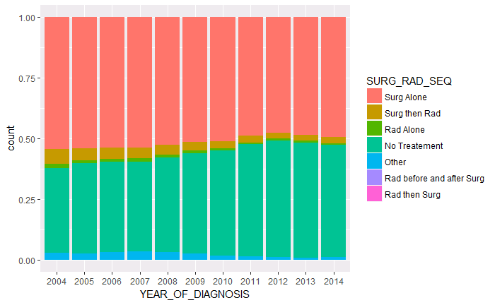

```r
data %>%
    ggplot(aes(x = YEAR_OF_DIAGNOSIS)) +
    geom_histogram(stat = "count", aes (fill = SURG_RAD_SEQ), position = "fill")
```

## Treatment by tumor size

```r
p_table(data,
        vars = c("SURG_RAD_SEQ"),
        strata = c("T_SIZE"))
```

```
|                 |           level           | No Tumor  | Microscopic focus |    < 1 cm    |   1-2 cm    |    2-3 cm    |   3-4 cm    |   4-5 cm    |   5-6 cm   |   >6 cm    |    NA_unk    |   p    | test |
|:----------------|:-------------------------:|:---------:|:-----------------:|:------------:|:-----------:|:------------:|:-----------:|:-----------:|:----------:|:----------:|:------------:|:------:|:----:|
|n                |                           |    30     |        83         |    16935     |    16815    |    15715     |    7080     |    2472     |    884     |    1324    |    15804     |        |      |
|SURG_RAD_SEQ (%) |        Surg Alone         | 15 (50.0) |     33 (39.8)     | 2907 (17.2)  | 7689 (45.7) | 10485 (66.7) | 5123 (72.4) | 1623 (65.7) | 484 (54.8) | 586 (44.3) | 10359 (65.5) | <0.001 |      |
|                 |       Surg then Rad       | 0 ( 0.0)  |     0 ( 0.0)      |  50 ( 0.3)   | 262 ( 1.6)  |  620 ( 3.9)  | 572 ( 8.1)  | 310 (12.5)  | 96 (10.9)  | 78 ( 5.9)  |  688 ( 4.4)  |        |      |
|                 |         Rad Alone         | 0 ( 0.0)  |     1 ( 1.2)      |  75 ( 0.4)   | 220 ( 1.3)  |  191 ( 1.2)  |  62 ( 0.9)  |  27 ( 1.1)  |  9 ( 1.0)  |  9 ( 0.7)  |  165 ( 1.0)  |        |      |
|                 |       No Treatement       | 15 (50.0) |     46 (55.4)     | 13456 (79.5) | 8292 (49.3) | 4181 (26.6)  | 1220 (17.2) | 469 (19.0)  | 281 (31.8) | 621 (46.9) | 4191 (26.5)  |        |      |
|                 |           Other           | 0 ( 0.0)  |     3 ( 3.6)      |  447 ( 2.6)  | 350 ( 2.1)  |  237 ( 1.5)  |  99 ( 1.4)  |  40 ( 1.6)  | 13 ( 1.5)  | 29 ( 2.2)  |  395 ( 2.5)  |        |      |
|                 | Rad before and after Surg | 0 ( 0.0)  |     0 ( 0.0)      |   0 ( 0.0)   |  0 ( 0.0)   |   0 ( 0.0)   |  0 ( 0.0)   |  0 ( 0.0)   |  1 ( 0.1)  |  0 ( 0.0)  |   0 ( 0.0)   |        |      |
|                 |       Rad then Surg       | 0 ( 0.0)  |     0 ( 0.0)      |   0 ( 0.0)   |  2 ( 0.0)   |   1 ( 0.0)   |  4 ( 0.1)   |  3 ( 0.1)   |  0 ( 0.0)  |  1 ( 0.1)  |   6 ( 0.0)   |        |      |
```

```
Ignoring unknown parameters: binwidth, bins, pad
```

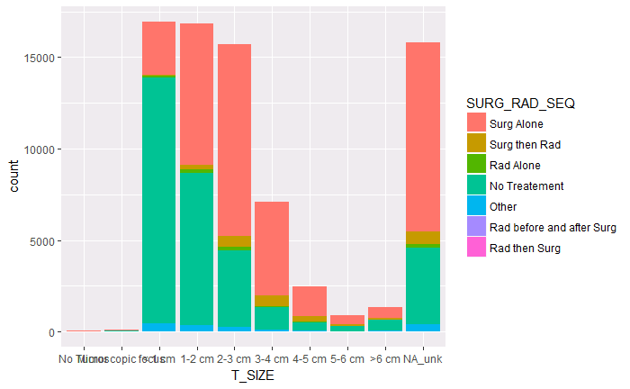

```r
data %>%
    ggplot(aes(x = T_SIZE)) +
    geom_histogram(stat = "count", aes (fill = SURG_RAD_SEQ))
```

# Tumor size by year

```r
p_table(data,
        vars = c("TUMOR_SIZE"),
        strata = c("YEAR_OF_DIAGNOSIS"))
```

```
|                       | level |      2004       |      2005       |      2006       |      2007       |      2008       |      2009       |      2010       |      2011       |      2012       |      2013       |      2014       |   p    | test |
|:----------------------|:-----:|:---------------:|:---------------:|:---------------:|:---------------:|:---------------:|:---------------:|:---------------:|:---------------:|:---------------:|:---------------:|:---------------:|:------:|:----:|
|n                      |       |      4410       |      5138       |      5645       |      6269       |      6782       |      7507       |      7584       |      7977       |      8633       |      8623       |      8574       |        |      |
|TUMOR_SIZE (mean (sd)) |       | 335.32 (456.98) | 329.50 (454.61) | 306.42 (444.65) | 278.12 (430.69) | 253.64 (417.06) | 239.28 (407.94) | 212.98 (389.47) | 189.63 (371.32) | 173.15 (356.41) | 163.96 (347.46) | 155.64 (338.74) | <0.001 |      |
```

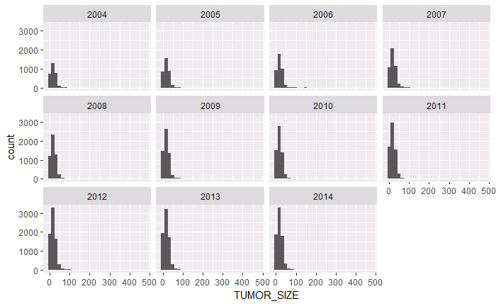

```r
data %>%
    filter(TUMOR_SIZE < 500) %>%
    ggplot(aes(x = TUMOR_SIZE)) +
    geom_histogram() +
    facet_wrap(~ YEAR_OF_DIAGNOSIS)
```

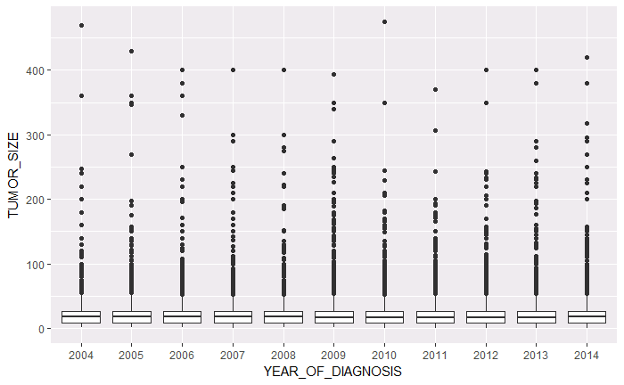

```r
data %>%
    filter(TUMOR_SIZE < 500) %>%
    ggplot(aes(x = YEAR_OF_DIAGNOSIS, y = TUMOR_SIZE)) +
    geom_boxplot()
```

## Treatment by facility

```r
p_table(data,
        vars = c("FACILITY_TYPE_F"),
        strata = c("RADIATION_YN"))
```

```
|                    |             level             |      No      |    Ukn     |     Yes     |   p    | test |
|:-------------------|:-----------------------------:|:------------:|:----------:|:-----------:|:------:|:----:|
|n                   |                               |    72879     |    806     |    3457     |        |      |
|FACILITY_TYPE_F (%) |   Community Cancer Program    | 2344 ( 3.2)  | 37 ( 4.6)  |  73 ( 2.1)  | <0.001 |      |
|                    | Comprehensive Comm Ca Program | 15901 (21.8) | 182 (22.6) | 1112 (32.2) |        |      |
|                    |   Academic/Research Program   | 26688 (36.6) | 265 (32.9) | 1260 (36.4) |        |      |
|                    | Integrated Network Ca Program | 6517 ( 8.9)  | 76 ( 9.4)  | 418 (12.1)  |        |      |
|                    |              NA               | 21429 (29.4) | 246 (30.5) | 594 (17.2)  |        |      |
```

## Variable for type of radiation

```r
data <- data %>%
        mutate(RAD_TYPE = case_when(RAD_REGIONAL_RX_MODALITY == "00" ~ "No Radiation",
                                    RAD_REGIONAL_RX_MODALITY == "20" ~ "External Beam, NOS",
                                    RAD_REGIONAL_RX_MODALITY == "21" ~ "Orthovoltage",
                                    RAD_REGIONAL_RX_MODALITY == "22" ~ "Cobalt-60, Cesium-137",
                                    RAD_REGIONAL_RX_MODALITY == "23" ~ "Photons (25 MV)",
                                    RAD_REGIONAL_RX_MODALITY == "24" ~ "Photons (610 MV)",
                                    RAD_REGIONAL_RX_MODALITY == "25" ~ "Photons (1119 MV)",
                                    RAD_REGIONAL_RX_MODALITY == "26" ~ "Photons (>19 MV)",
                                    RAD_REGIONAL_RX_MODALITY == "27" ~ "Photons (mixed energies)",
                                    RAD_REGIONAL_RX_MODALITY == "28" ~ "Electrons",
                                    RAD_REGIONAL_RX_MODALITY == "29" ~ "Photons and electrons mixed",
                                    RAD_REGIONAL_RX_MODALITY == "30" ~ "Neutron +/- Photons/Electrons",
                                    RAD_REGIONAL_RX_MODALITY == "31" ~ "IMRT",
                                    RAD_REGIONAL_RX_MODALITY == "32" ~ "Conformal or 3-D therapy",
                                    RAD_REGIONAL_RX_MODALITY == "40" ~ "Protons",
                                    RAD_REGIONAL_RX_MODALITY == "41" ~ "Stereotactic Surgery, NOS",
                                    RAD_REGIONAL_RX_MODALITY == "42" ~ "Linac",
                                    RAD_REGIONAL_RX_MODALITY == "43" ~ "Gamma Knife",
                                    RAD_REGIONAL_RX_MODALITY == "50" ~ "Brachytherapy, NOS",
                                    RAD_REGIONAL_RX_MODALITY == "51" ~ "Brachytherapy, Intracavitary, LDR",
                                    RAD_REGIONAL_RX_MODALITY == "52" ~ "Brachytherapy, Intracavitary, HDR",
                                    RAD_REGIONAL_RX_MODALITY == "53" ~ "Brachytherapy, Interstitial, LDR",
                                    RAD_REGIONAL_RX_MODALITY == "54" ~ "Brachytherapy, Interstitial, HDR",
                                    RAD_REGIONAL_RX_MODALITY == "55" ~ "Radium",
                                    RAD_REGIONAL_RX_MODALITY == "60" ~ "Radioisotopes, NOS",
                                    RAD_REGIONAL_RX_MODALITY == "61" ~ "Strontium-89",
                                    RAD_REGIONAL_RX_MODALITY == "62" ~ "Strontium-90",
                                    RAD_REGIONAL_RX_MODALITY == "80" ~ "Combination, specified",
                                    RAD_REGIONAL_RX_MODALITY == "85" ~ "Combination, NOS",
                                    RAD_REGIONAL_RX_MODALITY == "98" ~ "Other, NOS",
                                    RAD_REGIONAL_RX_MODALITY == "99" ~ "Unknown",
                                    TRUE ~ "NA/Unknown")) %>%
        mutate(RAD_DOSE = RAD_REGIONAL_DOSE_CGY)
p_table(data,
        vars = c("RAD_TYPE"))
```

```
|             |              level               |   Overall    |
|:------------|:--------------------------------:|:------------:|
|n            |                                  |    77142     |
|RAD_TYPE (%) | Brachytherapy, Interstitial, LDR |   1 ( 0.0)   |
|             |      Cobalt-60, Cesium-137       |   4 ( 0.0)   |
|             |     Conformal or 3-D therapy     |  126 ( 0.2)  |
|             |            Electrons             |   3 ( 0.0)   |
|             |        External Beam, NOS        |  252 ( 0.3)  |
|             |           Gamma Knife            |  813 ( 1.1)  |
|             |               IMRT               |  802 ( 1.0)  |
|             |              Linac               |  237 ( 0.3)  |
|             |  Neutron +/- Photons/Electrons   |   1 ( 0.0)   |
|             |           No Radiation           | 72879 (94.5) |
|             |            Other, NOS            |  18 ( 0.0)   |
|             |         Photons (>19 MV)         |  20 ( 0.0)   |
|             |        Photons (1119 MV)        |  82 ( 0.1)   |
|             |         Photons (25 MV)         |   3 ( 0.0)   |
|             |        Photons (610 MV)         |  590 ( 0.8)  |
|             |     Photons (mixed energies)     |  32 ( 0.0)   |
|             |             Protons              |  23 ( 0.0)   |
|             |        Radioisotopes, NOS        |   4 ( 0.0)   |
|             |    Stereotactic Surgery, NOS     |  446 ( 0.6)  |
|             |             Unknown              |  806 ( 1.0)  |
```

## Model for radiation as treatment

```r
fit_rad <- data %>%
        filter(T_SIZE != "Microscopic focus" & T_SIZE != "No Tumor") %>%
        filter(RADIATION_YN != "Ukn") %>%
        mutate(RADIATION_YN = case_when(RADIATION_YN == "Yes" ~ TRUE,
                                        RADIATION_YN == "No" ~ FALSE)) %>%
        glm(RADIATION_YN ~ FACILITY_TYPE_F + AGE_F + RACE_F + SEX_F +
                    CDCC_TOTAL + T_SIZE,
               family = "binomial",
            data = .)
summary(fit_rad)
```

```
Call:
glm(formula = RADIATION_YN ~ FACILITY_TYPE_F + AGE_F + RACE_F +
    SEX_F + CDCC_TOTAL + T_SIZE, family = "binomial", data = .)

Deviance Residuals:
    Min       1Q   Median       3Q      Max
-0.7216  -0.3694  -0.3039  -0.2304   3.3072

Coefficients:
                                             Estimate Std. Error z value Pr(>|z|)
(Intercept)                                  -5.02825    0.15933 -31.560  < 2e-16 ***
FACILITY_TYPE_FComprehensive Comm Ca Program  0.71046    0.12387   5.735 9.73e-09 ***
FACILITY_TYPE_FAcademic/Research Program      0.24680    0.12347   1.999  0.04562 *
FACILITY_TYPE_FIntegrated Network Ca Program  0.61070    0.13033   4.686 2.79e-06 ***
AGE_F(54,64]                                  0.11457    0.04901   2.338  0.01941 *
AGE_F(64,74]                                  0.05295    0.05305   0.998  0.31820
AGE_F(74,100]                                -0.14367    0.06359  -2.259  0.02386 *
RACE_FBlack                                  -0.21476    0.05159  -4.163 3.15e-05 ***
RACE_FOther/Unk                              -0.21152    0.11938  -1.772  0.07643 .
RACE_FAsian                                   0.01398    0.10435   0.134  0.89340
SEX_FFemale                                   0.22181    0.03934   5.639 1.71e-08 ***
CDCC_TOTAL1                                  -0.09588    0.05168  -1.855  0.06356 .
CDCC_TOTAL2                                  -0.17655    0.10188  -1.733  0.08311 .
CDCC_TOTAL3                                  -0.53944    0.19493  -2.767  0.00565 **
T_SIZE1-2 cm                                  1.16543    0.11533  10.105  < 2e-16 ***
T_SIZE2-3 cm                                  1.67619    0.11137  15.051  < 2e-16 ***
T_SIZE3-4 cm                                  2.26341    0.11375  19.898  < 2e-16 ***
T_SIZE4-5 cm                                  2.75463    0.12380  22.250  < 2e-16 ***
T_SIZE5-6 cm                                  2.62907    0.15901  16.534  < 2e-16 ***
T_SIZE>6 cm                                   2.06720    0.16524  12.511  < 2e-16 ***
T_SIZENA_unk                                  1.79425    0.11103  16.160  < 2e-16 ***
---
Signif. codes:  0 *** 0.001 ** 0.01 * 0.05 . 0.1   1

(Dispersion parameter for binomial family taken to be 1)

    Null deviance: 22410  on 54244  degrees of freedom
Residual deviance: 21248  on 54224  degrees of freedom
  (21978 observations deleted due to missingness)
AIC: 21290

Number of Fisher Scoring iterations: 7
```

### Forest plot

```
|Variable                                     |      Lower|  OddsRatio|      Upper|Sig   |
|:--------------------------------------------|----------:|----------:|----------:|:-----|
|FACILITY_TYPE_FComprehensive Comm Ca Program |  1.6082307|  2.0349345|  2.6153727|TRUE  |
|FACILITY_TYPE_FAcademic/Research Program     |  1.0123974|  1.2799187|  1.6437769|TRUE  |
|FACILITY_TYPE_FIntegrated Network Ca Program |  1.4358645|  1.8417194|  2.3949763|TRUE  |
|AGE_F(54,64]                                 |  1.0185323|  1.1213912|  1.2343076|TRUE  |
|AGE_F(64,74]                                 |  0.9499233|  1.0543778|  1.1695351|FALSE |
|AGE_F(74,100]                                |  0.7639061|  0.8661765|  0.9802174|TRUE  |
|RACE_FBlack                                  |  0.7284695|  0.8067370|  0.8917876|TRUE  |
|RACE_FOther/Unk                              |  0.6355973|  0.8093570|  1.0155188|FALSE |
|RACE_FAsian                                  |  0.8219646|  1.0140807|  1.2378477|FALSE |
|SEX_FFemale                                  |  1.1556801|  1.2483345|  1.3483751|TRUE  |
|CDCC_TOTAL1                                  |  0.8202931|  0.9085760|  1.0045321|FALSE |
|CDCC_TOTAL2                                  |  0.6827657|  0.8381561|  1.0183071|FALSE |
|CDCC_TOTAL3                                  |  0.3888772|  0.5830776|  0.8373766|TRUE  |
|T_SIZE1-2 cm                                 |  2.5707602|  3.2072939|  4.0422135|TRUE  |
|T_SIZE2-3 cm                                 |  4.3201985|  5.3451306|  6.6881593|TRUE  |
|T_SIZE3-4 cm                                 |  7.7333986|  9.6158516| 12.0847164|TRUE  |
|T_SIZE4-5 cm                                 | 12.3762171| 15.7152792| 20.1180259|TRUE  |
|T_SIZE5-6 cm                                 | 10.1336303| 13.8608283| 18.9186996|TRUE  |
|T_SIZE>6 cm                                  |  5.6972819|  7.9026936| 10.9016264|TRUE  |
|T_SIZENA_unk                                 |  4.8649379|  6.0149831|  7.5216086|TRUE  |
```

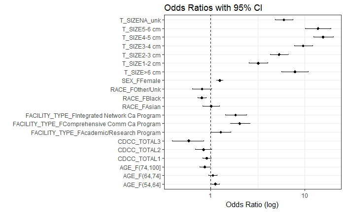

# Reduced to radiation only

```r
data <- data %>%
        filter(RADIATION_YN == "Yes")
```

## Table of variables for all cases:

```r
p_table(data,
        vars = c("FACILITY_TYPE_F", "FACILITY_LOCATION_F", "FACILITY_GEOGRAPHY",  "AGE", "AGE_F", "AGE_40",
                 "SEX_F", "RACE_F", "HISPANIC", "INSURANCE_F",
                 "INCOME_F", "EDUCATION_F", "U_R_F", "CROWFLY", "CDCC_TOTAL",
                 "PRIMARY_SITE", "HISTOLOGY_F_LIM", "HISTOLOGY_F", "BEHAVIOR", "GRADE_F",
                 "DX_STAGING_PROC_DAYS", "TNM_CLIN_T", "TNM_CLIN_N", "TNM_CLIN_M",
                 "TNM_CLIN_STAGE_GROUP", "TNM_PATH_T", "TNM_PATH_N", "TNM_PATH_M",
                 "TNM_PATH_STAGE_GROUP", "DX_RX_STARTED_DAYS", "DX_SURG_STARTED_DAYS",
                 "DX_DEFSURG_STARTED_DAYS", "MARGINS", "MARGINS_YN", "SURG_DISCHARGE_DAYS",
                 "READM_HOSP_30_DAYS_F", "RX_SUMM_RADIATION_F", "PUF_30_DAY_MORT_CD_F",
                 "PUF_90_DAY_MORT_CD_F", "DX_LASTCONTACT_DEATH_MONTHS",
                 "LYMPH_VASCULAR_INVASION_F", "RX_HOSP_SURG_APPR_2010_F", "SURG_RAD_SEQ",
                 "SURG_RAD_SEQ_C", "T_SIZE", "SURGERY_YN", "RADIATION_YN", "CHEMO_YN", "mets_at_dx", "CS_METS_AT_DX"))
```

```
|                                        |                level                |    Overall     |
|:---------------------------------------|:-----------------------------------:|:--------------:|
|n                                       |                                     |      3457      |
|FACILITY_TYPE_F (%)                     |      Community Cancer Program       |   73 (  2.1)   |
|                                        |    Comprehensive Comm Ca Program    |  1112 ( 32.2)  |
|                                        |      Academic/Research Program      |  1260 ( 36.4)  |
|                                        |    Integrated Network Ca Program    |  418 ( 12.1)   |
|                                        |                 NA                  |  594 ( 17.2)   |
|FACILITY_LOCATION_F (%)                 |             New England             |  135 (  3.9)   |
|                                        |           Middle Atlantic           |  368 ( 10.6)   |
|                                        |           South Atlantic            |  595 ( 17.2)   |
|                                        |         East North Central          |  428 ( 12.4)   |
|                                        |         East South Central          |  300 (  8.7)   |
|                                        |         West North Central          |  219 (  6.3)   |
|                                        |         West South Central          |  282 (  8.2)   |
|                                        |              Mountain               |  144 (  4.2)   |
|                                        |               Pacific               |  392 ( 11.3)   |
|                                        |                 NA                  |  594 ( 17.2)   |
|FACILITY_GEOGRAPHY (%)                  |              Northeast              |  503 ( 14.6)   |
|                                        |                South                |  877 ( 25.4)   |
|                                        |               Midwest               |  947 ( 27.4)   |
|                                        |                West                 |  536 ( 15.5)   |
|                                        |                 NA                  |  594 ( 17.2)   |
|AGE (mean (sd))                         |                                     | 55.25 (15.62)  |
|AGE_F (%)                               |               (0,54]                |  1616 ( 46.7)  |
|                                        |               (54,64]               |  826 ( 23.9)   |
|                                        |               (64,74]               |  640 ( 18.5)   |
|                                        |              (74,100]               |  375 ( 10.8)   |
|AGE_40 (%)                              |               (0,40]                |  643 ( 18.6)   |
|                                        |              (40,100]               |  2814 ( 81.4)  |
|SEX_F (%)                               |                Male                 |  1760 ( 50.9)  |
|                                        |               Female                |  1697 ( 49.1)  |
|RACE_F (%)                              |                White                |  2638 ( 76.3)  |
|                                        |                Black                |  586 ( 17.0)   |
|                                        |              Other/Unk              |  105 (  3.0)   |
|                                        |                Asian                |  128 (  3.7)   |
|HISPANIC (%)                            |                 No                  |  2891 ( 83.6)  |
|                                        |                 Yes                 |  342 (  9.9)   |
|                                        |               Unknown               |  224 (  6.5)   |
|INSURANCE_F (%)                         |               Private               |  1917 ( 55.5)  |
```

[output cut: 150 more lines]

```
|                                        |                 10                  |   0 (  0.0)    |
|                                        |                 12                  |   0 (  0.0)    |
|                                        |                 15                  |   0 (  0.0)    |
|                                        |                 20                  |   0 (  0.0)    |
|                                        |                 30                  |   0 (  0.0)    |
|                                        |                 35                  |   0 (  0.0)    |
|                                        |                 37                  |   0 (  0.0)    |
|                                        |                 40                  |   1 (  0.0)    |
|                                        |                 42                  |   0 (  0.0)    |
|                                        |                 43                  |   0 (  0.0)    |
|                                        |                 44                  |   0 (  0.0)    |
|                                        |                 45                  |   0 (  0.0)    |
|                                        |                 50                  |   1 (  0.0)    |
|                                        |                 60                  |   0 (  0.0)    |
|                                        |                 99                  |  422 ( 12.2)   |
```

```r
p_table(data,
        vars = c("RAD_TYPE"))
```

```
|             |              level               |  Overall   |
|:------------|:--------------------------------:|:----------:|
|n            |                                  |    3457    |
|RAD_TYPE (%) | Brachytherapy, Interstitial, LDR |  1 ( 0.0)  |
|             |      Cobalt-60, Cesium-137       |  4 ( 0.1)  |
|             |     Conformal or 3-D therapy     | 126 ( 3.6) |
|             |            Electrons             |  3 ( 0.1)  |
|             |        External Beam, NOS        | 252 ( 7.3) |
|             |           Gamma Knife            | 813 (23.5) |
|             |               IMRT               | 802 (23.2) |
|             |              Linac               | 237 ( 6.9) |
|             |  Neutron +/- Photons/Electrons   |  1 ( 0.0)  |
|             |            Other, NOS            | 18 ( 0.5)  |
|             |         Photons (>19 MV)         | 20 ( 0.6)  |
|             |        Photons (1119 MV)        | 82 ( 2.4)  |
|             |         Photons (25 MV)         |  3 ( 0.1)  |
|             |        Photons (610 MV)         | 590 (17.1) |
|             |     Photons (mixed energies)     | 32 ( 0.9)  |
|             |             Protons              | 23 ( 0.7)  |
|             |        Radioisotopes, NOS        |  4 ( 0.1)  |
|             |    Stereotactic Surgery, NOS     | 446 (12.9) |
```

```r
p_table(data,
        vars = c("RAD_TYPE"),
        strata = c("FACILITY_TYPE_F"))
```

```
|             |              level               | Community Cancer Program | Comprehensive Comm Ca Program | Academic/Research Program | Integrated Network Ca Program |   p    | test |
|:------------|:--------------------------------:|:------------------------:|:-----------------------------:|:-------------------------:|:-----------------------------:|:------:|:----:|
|n            |                                  |            73            |             1112              |           1260            |              418              |        |      |
|RAD_TYPE (%) | Brachytherapy, Interstitial, LDR |         0 ( 0.0)         |           0 ( 0.0)            |         1 ( 0.1)          |           0 ( 0.0)            | <0.001 |      |
|             |      Cobalt-60, Cesium-137       |         0 ( 0.0)         |           1 ( 0.1)            |         1 ( 0.1)          |           1 ( 0.2)            |        |      |
|             |     Conformal or 3-D therapy     |         2 ( 2.7)         |           47 ( 4.2)           |         44 ( 3.5)         |           15 ( 3.6)           |        |      |
|             |            Electrons             |         1 ( 1.4)         |           0 ( 0.0)            |         1 ( 0.1)          |           1 ( 0.2)            |        |      |
|             |        External Beam, NOS        |         6 ( 8.2)         |           56 ( 5.0)           |        115 ( 9.1)         |           26 ( 6.2)           |        |      |
|             |           Gamma Knife            |         6 ( 8.2)         |          221 (19.9)           |        341 (27.1)         |           71 (17.0)           |        |      |
|             |               IMRT               |        18 (24.7)         |          278 (25.0)           |        261 (20.7)         |          115 (27.5)           |        |      |
|             |              Linac               |         5 ( 6.8)         |           80 ( 7.2)           |         68 ( 5.4)         |           50 (12.0)           |        |      |
|             |  Neutron +/- Photons/Electrons   |         0 ( 0.0)         |           1 ( 0.1)            |         0 ( 0.0)          |           0 ( 0.0)            |        |      |
|             |            Other, NOS            |         1 ( 1.4)         |           7 ( 0.6)            |         6 ( 0.5)          |           2 ( 0.5)            |        |      |
|             |         Photons (>19 MV)         |         0 ( 0.0)         |           6 ( 0.5)            |         4 ( 0.3)          |           3 ( 0.7)            |        |      |
|             |        Photons (1119 MV)        |         4 ( 5.5)         |           35 ( 3.1)           |         20 ( 1.6)         |           10 ( 2.4)           |        |      |
|             |         Photons (25 MV)         |         0 ( 0.0)         |           0 ( 0.0)            |         1 ( 0.1)          |           0 ( 0.0)            |        |      |
|             |        Photons (610 MV)         |        23 (31.5)         |          198 (17.8)           |        209 (16.6)         |           65 (15.6)           |        |      |
|             |     Photons (mixed energies)     |         4 ( 5.5)         |           15 ( 1.3)           |         10 ( 0.8)         |           2 ( 0.5)            |        |      |
|             |             Protons              |         0 ( 0.0)         |           2 ( 0.2)            |         14 ( 1.1)         |           0 ( 0.0)            |        |      |
|             |        Radioisotopes, NOS        |         0 ( 0.0)         |           1 ( 0.1)            |         2 ( 0.2)          |           0 ( 0.0)            |        |      |
|             |    Stereotactic Surgery, NOS     |         3 ( 4.1)         |          164 (14.7)           |        162 (12.9)         |           57 (13.6)           |        |      |
```

# Kaplan Meier Analysis

```r
uni_var <- function(test_var, data_imp) {

        cat("_________________________________________________")
        cat("\n")
        cat("   \n##", test_var)
        cat("\n")
        cat("_________________________________________________")
        cat("\n")

        f <- as.formula(paste("Surv(DX_LASTCONTACT_DEATH_MONTHS, PUF_VITAL_STATUS == 0)",
                              as.name(test_var),
                              sep = " ~ " ))

        data_imp_2 <- deparse(substitute(data_imp))
        km_fit <- do.call("survfit", list(formula = f, data = as.name(data_imp_2)))
        print(km_fit)
        cat("\n")
        print(summary(km_fit, times = c(12, 24, 36, 48, 60, 120)))
        cat("\n")
        cat("\n")
        cat("\n")
        cat("   \n## Univariable Cox Proportional Hazard Model for: ", test_var)
        cat("\n")
        cat("\n")
        n_levels <- nlevels(data_imp[[test_var]])
        if(n_levels == 1){
                print("Only one level, no Cox model performed")
                cat("\n")
        } else {
                cox_fit <- do.call("coxph", list(formula = f, data = as.name(data_imp_2)))
                print(summary(cox_fit))
                cat("\n")

                do.call("ggforest",
                         list(model = cox_fit, data = as.name(data_imp_2)))
        }
        cat("\n")
        cat("\n")
        cat("\n")
        cat("   \n## Unadjusted Kaplan Meier Overall Survival Curve for: ", test_var)
        p <- do.call("ggsurvplot",
                     list(fit = km_fit, data = as.name(data_imp_2),
                          palette = "jco", censor = FALSE, legend = "right",
                          linetype = "strata", xlab = "Time (Months)"))
        print(p)
}
```

## All

```
_________________________________________________

## All
_________________________________________________
Call: survfit(formula = Surv(DX_LASTCONTACT_DEATH_MONTHS, PUF_VITAL_STATUS ==
    0) ~ All, data = data)

      n  events  median 0.95LCL 0.95UCL
   3457     539      NA      NA      NA

Call: survfit(formula = Surv(DX_LASTCONTACT_DEATH_MONTHS, PUF_VITAL_STATUS ==
    0) ~ All, data = data)

 time n.risk n.event survival std.err lower 95% CI upper 95% CI
   12   3241     103    0.970 0.00294        0.964        0.975
   24   2984      62    0.951 0.00375        0.943        0.958
   36   2591      72    0.926 0.00462        0.917        0.935
   48   2231      66    0.901 0.00544        0.890        0.912
   60   1858      57    0.876 0.00621        0.864        0.888
  120    367     167    0.741 0.01195        0.718        0.765




## Univariable Cox Proportional Hazard Model for:  All

[1] "Only one level, no Cox model performed"





## Unadjusted Kaplan Meier Overall Survival Curve for:  All
```

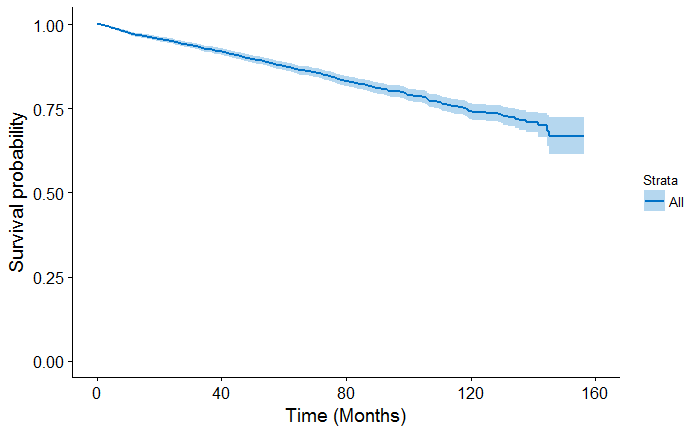

```r
uni_var(test_var = "All", data_imp = data)
```

## Facility Type

```
_________________________________________________

## FACILITY_TYPE_F
_________________________________________________
Call: survfit(formula = Surv(DX_LASTCONTACT_DEATH_MONTHS, PUF_VITAL_STATUS ==
    0) ~ FACILITY_TYPE_F, data = data)

   594 observations deleted due to missingness
                                                 n events median 0.95LCL 0.95UCL
FACILITY_TYPE_F=Community Cancer Program        73     27    117    77.2      NA
FACILITY_TYPE_F=Comprehensive Comm Ca Program 1112    239    145   144.6      NA
FACILITY_TYPE_F=Academic/Research Program     1260    189     NA      NA      NA
FACILITY_TYPE_F=Integrated Network Ca Program  418     67     NA      NA      NA

Call: survfit(formula = Surv(DX_LASTCONTACT_DEATH_MONTHS, PUF_VITAL_STATUS ==
    0) ~ FACILITY_TYPE_F, data = data)

594 observations deleted due to missingness
                FACILITY_TYPE_F=Community Cancer Program
 time n.risk n.event survival std.err lower 95% CI upper 95% CI
   12     65       8    0.890  0.0367        0.821        0.965
   24     59       2    0.862  0.0405        0.786        0.945
   36     52       2    0.830  0.0449        0.747        0.923
   48     41       5    0.741  0.0549        0.641        0.857
   60     32       4    0.667  0.0607        0.558        0.797
  120      7       6    0.493  0.0799        0.359        0.678

                FACILITY_TYPE_F=Comprehensive Comm Ca Program
 time n.risk n.event survival std.err lower 95% CI upper 95% CI
   12   1034      50    0.954 0.00630        0.942        0.967
   24    949      30    0.926 0.00796        0.911        0.942
   36    813      31    0.894 0.00958        0.875        0.913
   48    705      24    0.866 0.01086        0.845        0.887
   60    590      25    0.833 0.01228        0.809        0.857
  120     99      73    0.651 0.02330        0.607        0.699

                FACILITY_TYPE_F=Academic/Research Program
 time n.risk n.event survival std.err lower 95% CI upper 95% CI
   12   1191      37    0.970 0.00482        0.961        0.980
   24   1101      21    0.953 0.00607        0.941        0.965
```

[output cut: 29 more lines]

```
FACILITY_TYPE_FAcademic/Research Program     -1.0271    0.3580   0.2058 -4.991 6.02e-07 ***
FACILITY_TYPE_FIntegrated Network Ca Program -0.9909    0.3712   0.2282 -4.343 1.41e-05 ***
---
Signif. codes:  0 *** 0.001 ** 0.01 * 0.05 . 0.1   1

                                             exp(coef) exp(-coef) lower .95 upper .95
FACILITY_TYPE_FComprehensive Comm Ca Program    0.5329      1.877    0.3579    0.7934
FACILITY_TYPE_FAcademic/Research Program        0.3580      2.793    0.2392    0.5359
FACILITY_TYPE_FIntegrated Network Ca Program    0.3712      2.694    0.2374    0.5806

Concordance= 0.562  (se = 0.013 )
Rsquare= 0.011   (max possible= 0.932 )
Likelihood ratio test= 32.95  on 3 df,   p=3.306e-07
Wald test            = 36.29  on 3 df,   p=6.515e-08
Score (logrank) test = 37.9  on 3 df,   p=2.973e-08
```

```
Removed 1 rows containing missing values (geom_errorbar).
```

```
## Unadjusted Kaplan Meier Overall Survival Curve for:  FACILITY_TYPE_F
```

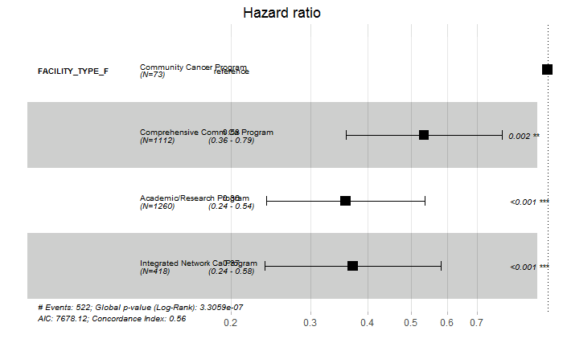

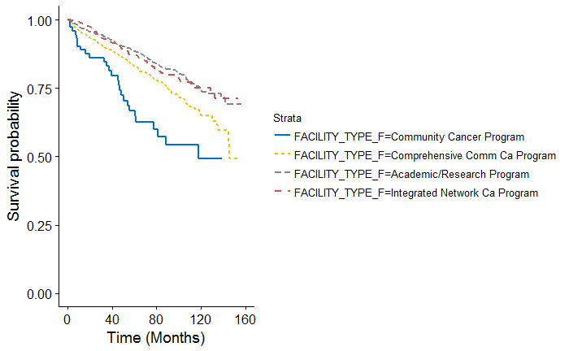

```r
uni_var(test_var = "FACILITY_TYPE_F", data_imp = data)
```

## Facility Location

```
_________________________________________________

## FACILITY_LOCATION_F
_________________________________________________
Call: survfit(formula = Surv(DX_LASTCONTACT_DEATH_MONTHS, PUF_VITAL_STATUS ==
    0) ~ FACILITY_LOCATION_F, data = data)

   594 observations deleted due to missingness
                                         n events median 0.95LCL 0.95UCL
FACILITY_LOCATION_F=New England        135     25     NA      NA      NA
FACILITY_LOCATION_F=Middle Atlantic    368     61     NA      NA      NA
FACILITY_LOCATION_F=South Atlantic     595    112     NA     145      NA
FACILITY_LOCATION_F=East North Central 428     81     NA     138      NA
FACILITY_LOCATION_F=East South Central 300     60     NA      NA      NA
FACILITY_LOCATION_F=West North Central 219     43     NA      NA      NA
FACILITY_LOCATION_F=West South Central 282     45     NA      NA      NA
FACILITY_LOCATION_F=Mountain           144     29     NA      NA      NA
FACILITY_LOCATION_F=Pacific            392     66     NA     145      NA

Call: survfit(formula = Surv(DX_LASTCONTACT_DEATH_MONTHS, PUF_VITAL_STATUS ==
    0) ~ FACILITY_LOCATION_F, data = data)

594 observations deleted due to missingness
                FACILITY_LOCATION_F=New England
 time n.risk n.event survival std.err lower 95% CI upper 95% CI
   12    132       3    0.978  0.0127        0.953        1.000
   24    123       2    0.963  0.0164        0.931        0.995
   36    106       4    0.929  0.0228        0.886        0.975
   48     92       5    0.884  0.0294        0.828        0.943
   60     75       2    0.863  0.0322        0.802        0.928
  120     11       9    0.677  0.0687        0.555        0.826

                FACILITY_LOCATION_F=Middle Atlantic
 time n.risk n.event survival std.err lower 95% CI upper 95% CI
   12    345      10    0.972 0.00868        0.955        0.989
   24    322       6    0.955 0.01102        0.934        0.977
   36    295       6    0.937 0.01311        0.911        0.963
   48    243      14    0.889 0.01762        0.855        0.924
   60    197      10    0.848 0.02093        0.808        0.890
  120     41      15    0.721 0.03854        0.649        0.801
```

[output cut: 87 more lines]

```
                                      exp(coef) exp(-coef) lower .95 upper .95
FACILITY_LOCATION_FMiddle Atlantic       0.8866     1.1279    0.5566     1.412
FACILITY_LOCATION_FSouth Atlantic        1.0507     0.9518    0.6809     1.621
FACILITY_LOCATION_FEast North Central    1.0153     0.9849    0.6483     1.590
FACILITY_LOCATION_FEast South Central    1.0167     0.9835    0.6375     1.622
FACILITY_LOCATION_FWest North Central    1.0608     0.9427    0.6479     1.737
FACILITY_LOCATION_FWest South Central    0.9082     1.1011    0.5569     1.481
FACILITY_LOCATION_FMountain              1.1773     0.8494    0.6895     2.010
FACILITY_LOCATION_FPacific               0.8619     1.1602    0.5438     1.366

Concordance= 0.532  (se = 0.014 )
Rsquare= 0.001   (max possible= 0.932 )
Likelihood ratio test= 3.93  on 8 df,   p=0.8635
Wald test            = 3.91  on 8 df,   p=0.8653
Score (logrank) test = 3.92  on 8 df,   p=0.8642
```

```
Removed 1 rows containing missing values (geom_errorbar).
```

```
## Unadjusted Kaplan Meier Overall Survival Curve for:  FACILITY_LOCATION_F
```

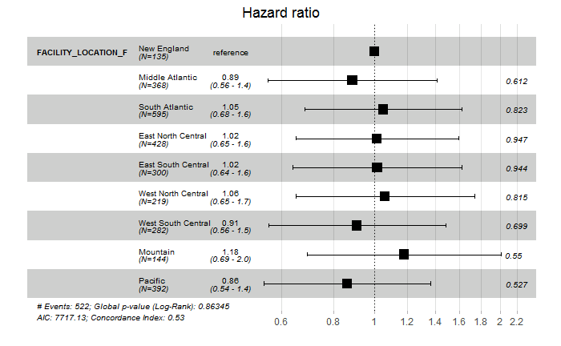

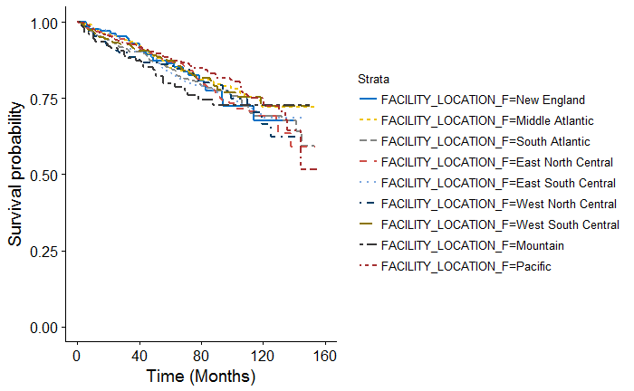

```r
uni_var(test_var = "FACILITY_LOCATION_F", data_imp = data)
```

## Facility Geography

```
_________________________________________________

## FACILITY_GEOGRAPHY
_________________________________________________
Call: survfit(formula = Surv(DX_LASTCONTACT_DEATH_MONTHS, PUF_VITAL_STATUS ==
    0) ~ FACILITY_GEOGRAPHY, data = data)

   594 observations deleted due to missingness
                               n events median 0.95LCL 0.95UCL
FACILITY_GEOGRAPHY=Northeast 503     86     NA      NA      NA
FACILITY_GEOGRAPHY=South     877    157     NA      NA      NA
FACILITY_GEOGRAPHY=Midwest   947    184     NA      NA      NA
FACILITY_GEOGRAPHY=West      536     95     NA     145      NA

Call: survfit(formula = Surv(DX_LASTCONTACT_DEATH_MONTHS, PUF_VITAL_STATUS ==
    0) ~ FACILITY_GEOGRAPHY, data = data)

594 observations deleted due to missingness
                FACILITY_GEOGRAPHY=Northeast
 time n.risk n.event survival std.err lower 95% CI upper 95% CI
   12    477      13    0.974 0.00719        0.960        0.988
   24    445       8    0.957 0.00918        0.939        0.975
   36    401      10    0.935 0.01136        0.913        0.957
   48    335      19    0.888 0.01510        0.858        0.918
   60    272      12    0.852 0.01757        0.819        0.888
  120     52      24    0.709 0.03381        0.646        0.778

                FACILITY_GEOGRAPHY=South
 time n.risk n.event survival std.err lower 95% CI upper 95% CI
   12    811      36    0.958 0.00683        0.945        0.972
   24    724      22    0.931 0.00873        0.914        0.948
   36    608      17    0.908 0.01021        0.888        0.928
   48    537      17    0.881 0.01181        0.858        0.904
   60    450      13    0.858 0.01309        0.833        0.884
  120     85      49    0.703 0.02478        0.656        0.753

                FACILITY_GEOGRAPHY=Midwest
 time n.risk n.event survival std.err lower 95% CI upper 95% CI
   12    897      29    0.969 0.00566        0.958        0.980
   24    838      20    0.947 0.00735        0.933        0.962
```

[output cut: 27 more lines]

```
                             coef exp(coef) se(coef)     z Pr(>|z|)
FACILITY_GEOGRAPHYSouth   0.09231   1.09670  0.13422 0.688    0.492
FACILITY_GEOGRAPHYMidwest 0.11263   1.11922  0.13064 0.862    0.389
FACILITY_GEOGRAPHYWest    0.02371   1.02400  0.14892 0.159    0.873

                          exp(coef) exp(-coef) lower .95 upper .95
FACILITY_GEOGRAPHYSouth       1.097     0.9118    0.8430     1.427
FACILITY_GEOGRAPHYMidwest     1.119     0.8935    0.8664     1.446
FACILITY_GEOGRAPHYWest        1.024     0.9766    0.7648     1.371

Concordance= 0.51  (se = 0.013 )
Rsquare= 0   (max possible= 0.932 )
Likelihood ratio test= 1.04  on 3 df,   p=0.7904
Wald test            = 1.04  on 3 df,   p=0.7926
Score (logrank) test = 1.04  on 3 df,   p=0.7924
```

```
Removed 1 rows containing missing values (geom_errorbar).
```

```
## Unadjusted Kaplan Meier Overall Survival Curve for:  FACILITY_GEOGRAPHY
```

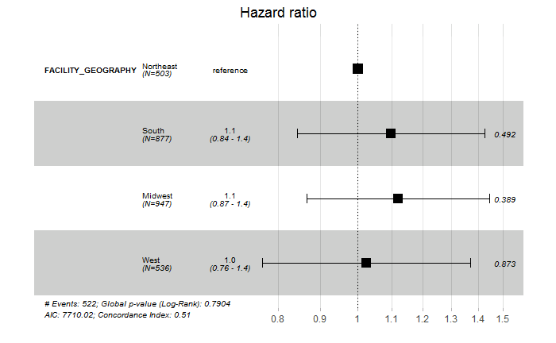

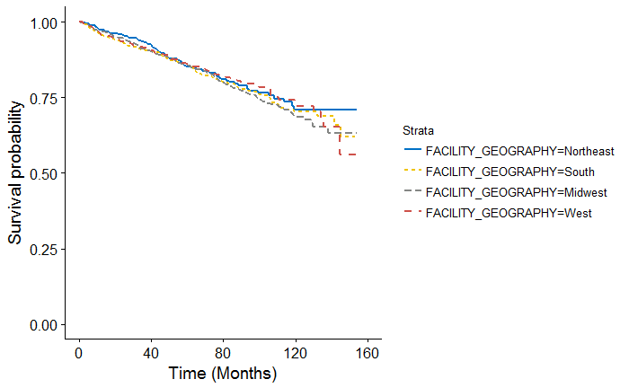

```r
uni_var(test_var = "FACILITY_GEOGRAPHY", data_imp = data)
```

## Age Group

```
_________________________________________________

## AGE_F
_________________________________________________
Call: survfit(formula = Surv(DX_LASTCONTACT_DEATH_MONTHS, PUF_VITAL_STATUS ==
    0) ~ AGE_F, data = data)

                  n events median 0.95LCL 0.95UCL
AGE_F=(0,54]   1616     84     NA      NA      NA
AGE_F=(54,64]   826    101     NA      NA      NA
AGE_F=(64,74]   640    142  141.6   129.6      NA
AGE_F=(74,100]  375    212   62.3    55.4    72.2

Call: survfit(formula = Surv(DX_LASTCONTACT_DEATH_MONTHS, PUF_VITAL_STATUS ==
    0) ~ AGE_F, data = data)

                AGE_F=(0,54]
 time n.risk n.event survival std.err lower 95% CI upper 95% CI
   12   1541      11    0.993 0.00208        0.989        0.997
   24   1431       9    0.987 0.00286        0.982        0.993
   36   1269      14    0.977 0.00393        0.969        0.985
   48   1119       9    0.970 0.00460        0.961        0.979
   60    965       8    0.962 0.00526        0.952        0.973
  120    202      31    0.907 0.01183        0.884        0.930

                AGE_F=(54,64]
 time n.risk n.event survival std.err lower 95% CI upper 95% CI
   12    781      20    0.975 0.00543        0.965        0.986
   24    738      10    0.963 0.00667        0.950        0.976
   36    644       9    0.950 0.00778        0.935        0.966
   48    559       9    0.936 0.00898        0.919        0.954
   60    452      12    0.914 0.01086        0.893        0.935
  120     93      39    0.783 0.02309        0.739        0.829

                AGE_F=(64,74]
 time n.risk n.event survival std.err lower 95% CI upper 95% CI
   12    589      31    0.951 0.00863        0.934        0.968
   24    534      12    0.931 0.01020        0.911        0.951
   36    452      19    0.895 0.01265        0.871        0.920
   48    375      19    0.854 0.01518        0.825        0.885
```

[output cut: 26 more lines]

```
AGE_F(64,74]   1.6223    5.0648   0.1378 11.772  < 2e-16 ***
AGE_F(74,100]  2.8035   16.5031   0.1298 21.595  < 2e-16 ***
---
Signif. codes:  0 *** 0.001 ** 0.01 * 0.05 . 0.1   1

              exp(coef) exp(-coef) lower .95 upper .95
AGE_F(54,64]      2.468    0.40522     1.847     3.296
AGE_F(64,74]      5.065    0.19744     3.866     6.636
AGE_F(74,100]    16.503    0.06059    12.795    21.285

Concordance= 0.757  (se = 0.013 )
Rsquare= 0.148   (max possible= 0.906 )
Likelihood ratio test= 553.6  on 3 df,   p=0
Wald test            = 555  on 3 df,   p=0
Score (logrank) test = 832.4  on 3 df,   p=0
```

```
Removed 1 rows containing missing values (geom_errorbar).
```

```
## Unadjusted Kaplan Meier Overall Survival Curve for:  AGE_F
```

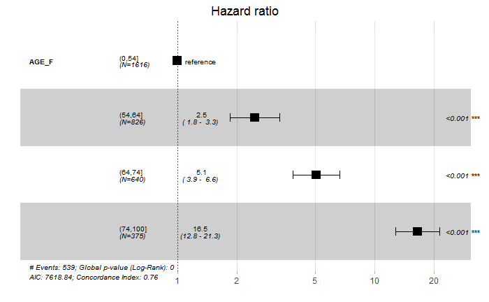

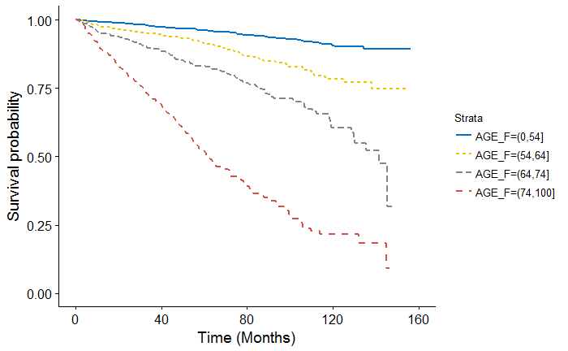

```r
uni_var(test_var = "AGE_F", data_imp = data)
```

## Age Group

```
_________________________________________________

## AGE_40
_________________________________________________
Call: survfit(formula = Surv(DX_LASTCONTACT_DEATH_MONTHS, PUF_VITAL_STATUS ==
    0) ~ AGE_40, data = data)

                   n events median 0.95LCL 0.95UCL
AGE_40=(0,40]    643     19     NA      NA      NA
AGE_40=(40,100] 2814    520     NA      NA      NA

Call: survfit(formula = Surv(DX_LASTCONTACT_DEATH_MONTHS, PUF_VITAL_STATUS ==
    0) ~ AGE_40, data = data)

                AGE_40=(0,40]
 time n.risk n.event survival std.err lower 95% CI upper 95% CI
   12    604       3    0.995 0.00278        0.990        1.000
   24    558       1    0.994 0.00322        0.987        1.000
   36    485       4    0.986 0.00503        0.976        0.996
   48    425       3    0.979 0.00623        0.967        0.992
   60    356       2    0.974 0.00720        0.960        0.988
  120     60       6    0.951 0.01187        0.928        0.974

                AGE_40=(40,100]
 time n.risk n.event survival std.err lower 95% CI upper 95% CI
   12   2637     100    0.964 0.00354        0.957        0.971
   24   2426      61    0.941 0.00451        0.932        0.950
   36   2106      68    0.913 0.00550        0.902        0.924
   48   1806      63    0.884 0.00644        0.871        0.897
   60   1502      55    0.855 0.00732        0.841        0.869
  120    307     161    0.700 0.01367        0.674        0.727





## Univariable Cox Proportional Hazard Model for:  AGE_40

Call:
coxph(formula = Surv(DX_LASTCONTACT_DEATH_MONTHS, PUF_VITAL_STATUS ==
    0) ~ AGE_40, data = data)

  n= 3457, number of events= 539

                 coef exp(coef) se(coef)     z Pr(>|z|)
AGE_40(40,100] 1.8460    6.3341   0.2336 7.903 2.78e-15 ***
---
Signif. codes:  0 *** 0.001 ** 0.01 * 0.05 . 0.1   1

               exp(coef) exp(-coef) lower .95 upper .95
AGE_40(40,100]     6.334     0.1579     4.007     10.01

Concordance= 0.576  (se = 0.009 )
Rsquare= 0.033   (max possible= 0.906 )
Likelihood ratio test= 115.6  on 1 df,   p=0
Wald test            = 62.46  on 1 df,   p=2.776e-15
Score (logrank) test = 82.33  on 1 df,   p=0
```

```
Removed 1 rows containing missing values (geom_errorbar).
```

```
## Unadjusted Kaplan Meier Overall Survival Curve for:  AGE_40
```

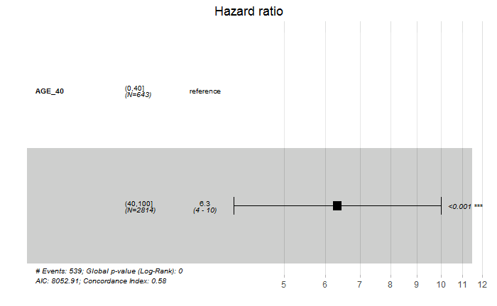

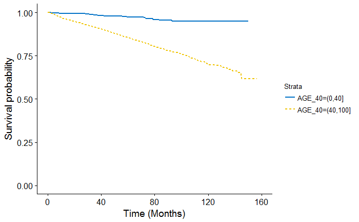

```r
uni_var(test_var = "AGE_40", data_imp = data)
```

## Gender

```
_________________________________________________

## SEX_F
_________________________________________________
Call: survfit(formula = Surv(DX_LASTCONTACT_DEATH_MONTHS, PUF_VITAL_STATUS ==
    0) ~ SEX_F, data = data)

                n events median 0.95LCL 0.95UCL
SEX_F=Male   1760    296     NA      NA      NA
SEX_F=Female 1697    243     NA      NA      NA

Call: survfit(formula = Surv(DX_LASTCONTACT_DEATH_MONTHS, PUF_VITAL_STATUS ==
    0) ~ SEX_F, data = data)

                SEX_F=Male
 time n.risk n.event survival std.err lower 95% CI upper 95% CI
   12   1635      63    0.964 0.00451        0.955        0.972
   24   1509      32    0.944 0.00556        0.933        0.955
   36   1306      42    0.916 0.00686        0.903        0.930
   48   1119      36    0.889 0.00802        0.874        0.905
   60    929      32    0.862 0.00912        0.844        0.880
  120    188      85    0.723 0.01722        0.690        0.757

                SEX_F=Female
 time n.risk n.event survival std.err lower 95% CI upper 95% CI
   12   1606      40    0.976 0.00375        0.969        0.983
   24   1475      30    0.957 0.00500        0.948        0.967
   36   1285      30    0.936 0.00617        0.924        0.949
   48   1112      30    0.913 0.00732        0.899        0.928
   60    929      25    0.891 0.00839        0.875        0.908
  120    179      82    0.761 0.01633        0.729        0.793





## Univariable Cox Proportional Hazard Model for:  SEX_F

Call:
coxph(formula = Surv(DX_LASTCONTACT_DEATH_MONTHS, PUF_VITAL_STATUS ==
    0) ~ SEX_F, data = data)

  n= 3457, number of events= 539

                coef exp(coef) se(coef)      z Pr(>|z|)
SEX_FFemale -0.16180   0.85061  0.08659 -1.869   0.0617 .
---
Signif. codes:  0 *** 0.001 ** 0.01 * 0.05 . 0.1   1

            exp(coef) exp(-coef) lower .95 upper .95
SEX_FFemale    0.8506      1.176    0.7178     1.008

Concordance= 0.526  (se = 0.012 )
Rsquare= 0.001   (max possible= 0.906 )
Likelihood ratio test= 3.51  on 1 df,   p=0.06114
Wald test            = 3.49  on 1 df,   p=0.06169
Score (logrank) test = 3.5  on 1 df,   p=0.0614
```

```
Removed 1 rows containing missing values (geom_errorbar).
```

```
## Unadjusted Kaplan Meier Overall Survival Curve for:  SEX_F
```

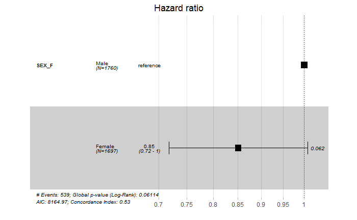

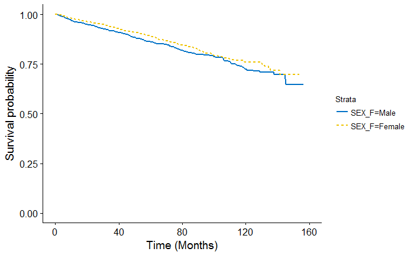

```r
uni_var(test_var = "SEX_F", data_imp = data)
```

## RACE_F

```
_________________________________________________

## RACE_F
_________________________________________________
Call: survfit(formula = Surv(DX_LASTCONTACT_DEATH_MONTHS, PUF_VITAL_STATUS ==
    0) ~ RACE_F, data = data)

                    n events median 0.95LCL 0.95UCL
RACE_F=White     2638    430     NA      NA      NA
RACE_F=Black      586     88     NA      NA      NA
RACE_F=Other/Unk  105      9     NA      NA      NA
RACE_F=Asian      128     12     NA      NA      NA

Call: survfit(formula = Surv(DX_LASTCONTACT_DEATH_MONTHS, PUF_VITAL_STATUS ==
    0) ~ RACE_F, data = data)

                RACE_F=White
 time n.risk n.event survival std.err lower 95% CI upper 95% CI
   12   2477      80    0.969 0.00340        0.962        0.976
   24   2283      48    0.950 0.00432        0.941        0.958
   36   1983      62    0.922 0.00542        0.912        0.933
   48   1704      53    0.896 0.00636        0.884        0.909
   60   1420      45    0.871 0.00723        0.857        0.885
  120    280     135    0.727 0.01414        0.699        0.755

                RACE_F=Black
 time n.risk n.event survival std.err lower 95% CI upper 95% CI
   12    550      16    0.972 0.00685        0.959        0.986
   24    506      12    0.951 0.00912        0.933        0.969
   36    440       9    0.933 0.01069        0.912        0.954
   48    385       8    0.915 0.01222        0.891        0.939
   60    319      11    0.887 0.01450        0.859        0.916
  120     60      27    0.760 0.02691        0.709        0.814

                RACE_F=Other/Unk
 time n.risk n.event survival std.err lower 95% CI upper 95% CI
   12     95       3    0.970  0.0169        0.938        1.000
   24     84       1    0.959  0.0199        0.921        0.999
   36     69       1    0.946  0.0237        0.901        0.994
   48     61       2    0.916  0.0309        0.858        0.979
```

[output cut: 26 more lines]

```
RACE_FOther/Unk -0.5730    0.5638   0.3368 -1.701   0.0889 .
RACE_FAsian     -0.5832    0.5581   0.2927 -1.993   0.0463 *
---
Signif. codes:  0 *** 0.001 ** 0.01 * 0.05 . 0.1   1

                exp(coef) exp(-coef) lower .95 upper .95
RACE_FBlack        0.9217      1.085    0.7328    1.1593
RACE_FOther/Unk    0.5639      1.774    0.2914    1.0911
RACE_FAsian        0.5581      1.792    0.3145    0.9905

Concordance= 0.519  (se = 0.01 )
Rsquare= 0.002   (max possible= 0.906 )
Likelihood ratio test= 8.18  on 3 df,   p=0.04238
Wald test            = 6.93  on 3 df,   p=0.07426
Score (logrank) test = 7.1  on 3 df,   p=0.06867
```

```
Removed 1 rows containing missing values (geom_errorbar).
```

```
## Unadjusted Kaplan Meier Overall Survival Curve for:  RACE_F
```

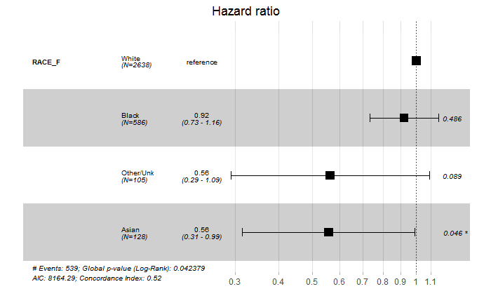

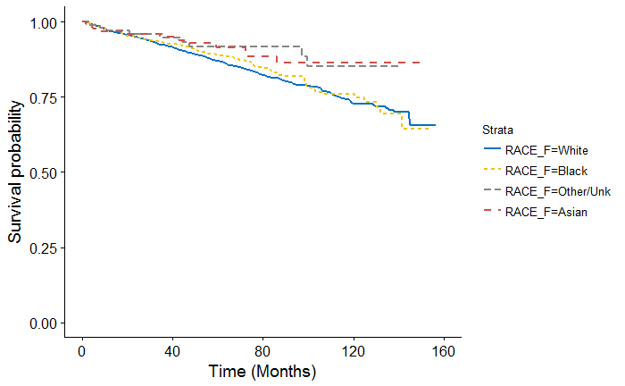

```r
uni_var(test_var = "RACE_F", data_imp = data)
```

## Hispanic

```
_________________________________________________

## HISPANIC
_________________________________________________
Call: survfit(formula = Surv(DX_LASTCONTACT_DEATH_MONTHS, PUF_VITAL_STATUS ==
    0) ~ HISPANIC, data = data)

                    n events median 0.95LCL 0.95UCL
HISPANIC=No      2891    462     NA      NA      NA
HISPANIC=Yes      342     40     NA      NA      NA
HISPANIC=Unknown  224     37     NA      NA      NA

Call: survfit(formula = Surv(DX_LASTCONTACT_DEATH_MONTHS, PUF_VITAL_STATUS ==
    0) ~ HISPANIC, data = data)

                HISPANIC=No
 time n.risk n.event survival std.err lower 95% CI upper 95% CI
   12   2726      86    0.970 0.00321        0.964        0.976
   24   2520      50    0.952 0.00406        0.944        0.960
   36   2186      65    0.925 0.00507        0.916        0.935
   48   1871      57    0.900 0.00598        0.888        0.911
   60   1557      48    0.875 0.00681        0.861        0.888
  120    318     144    0.739 0.01290        0.714        0.765

                HISPANIC=Yes
 time n.risk n.event survival std.err lower 95% CI upper 95% CI
   12    310       9    0.973  0.0090        0.955        0.990
   24    271       8    0.947  0.0125        0.923        0.972
   36    232       4    0.932  0.0145        0.904        0.960
   48    206       4    0.914  0.0166        0.882        0.947
   60    164       5    0.890  0.0195        0.852        0.929
  120     24      10    0.796  0.0348        0.731        0.867

                HISPANIC=Unknown
 time n.risk n.event survival std.err lower 95% CI upper 95% CI
   12    205       8    0.963  0.0127        0.939        0.989
   24    193       4    0.944  0.0157        0.914        0.975
   36    173       3    0.929  0.0176        0.895        0.964
   48    154       5    0.901  0.0210        0.861        0.944
   60    137       4    0.877  0.0237        0.832        0.925
```

[output cut: 12 more lines]

```
  n= 3457, number of events= 539

                   coef exp(coef) se(coef)      z Pr(>|z|)
HISPANICYes     -0.1913    0.8258   0.1649 -1.161    0.246
HISPANICUnknown -0.0305    0.9700   0.1709 -0.178    0.858

                exp(coef) exp(-coef) lower .95 upper .95
HISPANICYes        0.8258      1.211    0.5978     1.141
HISPANICUnknown    0.9700      1.031    0.6939     1.356

Concordance= 0.506  (se = 0.009 )
Rsquare= 0   (max possible= 0.906 )
Likelihood ratio test= 1.43  on 2 df,   p=0.4897
Wald test            = 1.35  on 2 df,   p=0.5079
Score (logrank) test = 1.36  on 2 df,   p=0.5069
```

```
Removed 1 rows containing missing values (geom_errorbar).
```

```
## Unadjusted Kaplan Meier Overall Survival Curve for:  HISPANIC
```

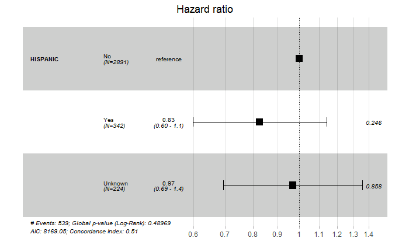

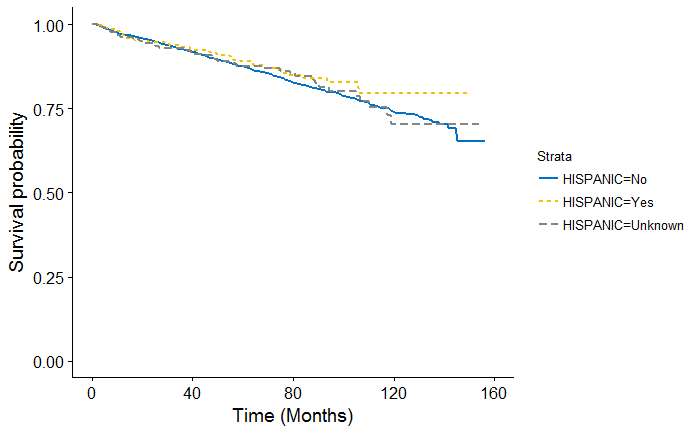

```r
uni_var(test_var = "HISPANIC", data_imp = data)
```

## Insurance Status

```
_________________________________________________

## INSURANCE_F
_________________________________________________
Call: survfit(formula = Surv(DX_LASTCONTACT_DEATH_MONTHS, PUF_VITAL_STATUS ==
    0) ~ INSURANCE_F, data = data)

                                n events median 0.95LCL 0.95UCL
INSURANCE_F=Private          1917    141     NA      NA      NA
INSURANCE_F=None              125     14     NA      NA      NA
INSURANCE_F=Medicaid          265     36     NA      NA      NA
INSURANCE_F=Medicare         1044    326    119     114     145
INSURANCE_F=Other Government   50     11    120     107      NA
INSURANCE_F=Unknown            56     11     NA      NA      NA

Call: survfit(formula = Surv(DX_LASTCONTACT_DEATH_MONTHS, PUF_VITAL_STATUS ==
    0) ~ INSURANCE_F, data = data)

                INSURANCE_F=Private
 time n.risk n.event survival std.err lower 95% CI upper 95% CI
   12   1839      19    0.990 0.00230        0.985        0.994
   24   1723      15    0.982 0.00312        0.976        0.988
   36   1525      25    0.967 0.00427        0.958        0.975
   48   1350      11    0.959 0.00480        0.950        0.969
   60   1151      13    0.949 0.00549        0.939        0.960
  120    248      56    0.869 0.01232        0.845        0.893

                INSURANCE_F=None
 time n.risk n.event survival std.err lower 95% CI upper 95% CI
   12    110       5    0.959  0.0180        0.924        0.995
   24     97       2    0.941  0.0216        0.900        0.984
   36     86       0    0.941  0.0216        0.900        0.984
   48     70       2    0.918  0.0267        0.867        0.972
   60     57       4    0.859  0.0379        0.788        0.936
  120     14       1    0.829  0.0468        0.742        0.926

                INSURANCE_F=Medicaid
 time n.risk n.event survival std.err lower 95% CI upper 95% CI
   12    241       9    0.965  0.0114        0.943        0.988
   24    215       6    0.941  0.0149        0.912        0.970
```

[output cut: 50 more lines]

```
---
Signif. codes:  0 *** 0.001 ** 0.01 * 0.05 . 0.1   1

                            exp(coef) exp(-coef) lower .95 upper .95
INSURANCE_FNone                 1.875     0.5333     1.082     3.248
INSURANCE_FMedicaid             2.454     0.4075     1.701     3.540
INSURANCE_FMedicare             5.219     0.1916     4.281     6.363
INSURANCE_FOther Government     3.435     0.2911     1.859     6.347
INSURANCE_FUnknown              2.657     0.3764     1.438     4.908

Concordance= 0.691  (se = 0.012 )
Rsquare= 0.084   (max possible= 0.906 )
Likelihood ratio test= 301.9  on 5 df,   p=0
Wald test            = 273.2  on 5 df,   p=0
Score (logrank) test = 332.6  on 5 df,   p=0
```

```
Removed 1 rows containing missing values (geom_errorbar).
```

```
## Unadjusted Kaplan Meier Overall Survival Curve for:  INSURANCE_F
```

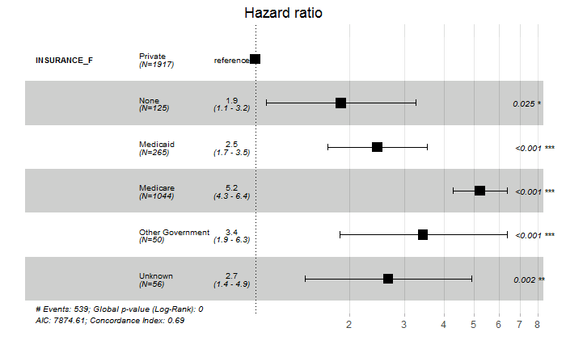

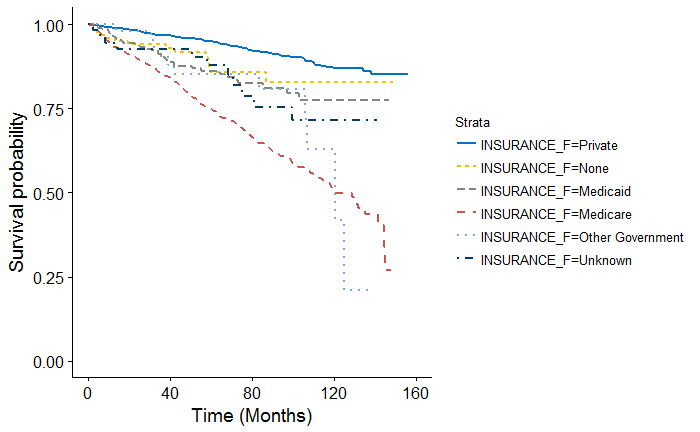

```r
uni_var(test_var = "INSURANCE_F", data_imp = data)
```

## Income

```
_________________________________________________

## INCOME_F
_________________________________________________
Call: survfit(formula = Surv(DX_LASTCONTACT_DEATH_MONTHS, PUF_VITAL_STATUS ==
    0) ~ INCOME_F, data = data)

   29 observations deleted due to missingness
                              n events median 0.95LCL 0.95UCL
INCOME_F=Less than $38,000  667    125     NA     145      NA
INCOME_F=$38,000 - $47,999  831    137     NA      NA      NA
INCOME_F=$48,000 - $62,999  911    135     NA      NA      NA
INCOME_F=$63,000 +         1019    134     NA      NA      NA

Call: survfit(formula = Surv(DX_LASTCONTACT_DEATH_MONTHS, PUF_VITAL_STATUS ==
    0) ~ INCOME_F, data = data)

29 observations deleted due to missingness
                INCOME_F=Less than $38,000
 time n.risk n.event survival std.err lower 95% CI upper 95% CI
   12    621      27    0.959 0.00777        0.944        0.974
   24    568      16    0.933 0.00982        0.914        0.953
   36    494      12    0.912 0.01135        0.890        0.935
   48    421      17    0.879 0.01355        0.852        0.906
   60    348      16    0.843 0.01564        0.813        0.874
  120     66      36    0.707 0.02598        0.658        0.760

                INCOME_F=$38,000 - $47,999
 time n.risk n.event survival std.err lower 95% CI upper 95% CI
   12    776      26    0.968 0.00613        0.956        0.980
   24    714      17    0.947 0.00792        0.931        0.962
   36    628      17    0.923 0.00958        0.904        0.942
   48    555      18    0.895 0.01130        0.873        0.918
   60    460      12    0.874 0.01258        0.850        0.899
  120     83      46    0.713 0.02617        0.663        0.766

                INCOME_F=$48,000 - $62,999
 time n.risk n.event survival std.err lower 95% CI upper 95% CI
   12    850      25    0.972 0.00554        0.961        0.983
   24    789      14    0.956 0.00697        0.942        0.969
```

[output cut: 29 more lines]

```
INCOME_F$48,000 - $62,999 -0.2398    0.7868   0.1241 -1.932 0.053361 .
INCOME_F$63,000 +         -0.4111    0.6629   0.1244 -3.305 0.000949 ***
---
Signif. codes:  0 *** 0.001 ** 0.01 * 0.05 . 0.1   1

                          exp(coef) exp(-coef) lower .95 upper .95
INCOME_F$38,000 - $47,999    0.8469      1.181    0.6646    1.0793
INCOME_F$48,000 - $62,999    0.7868      1.271    0.6168    1.0035
INCOME_F$63,000 +            0.6629      1.509    0.5195    0.8459

Concordance= 0.547  (se = 0.013 )
Rsquare= 0.003   (max possible= 0.904 )
Likelihood ratio test= 11.29  on 3 df,   p=0.01027
Wald test            = 11.31  on 3 df,   p=0.01018
Score (logrank) test = 11.41  on 3 df,   p=0.00972
```

```
Removed 1 rows containing missing values (geom_errorbar).
```

```
## Unadjusted Kaplan Meier Overall Survival Curve for:  INCOME_F
```

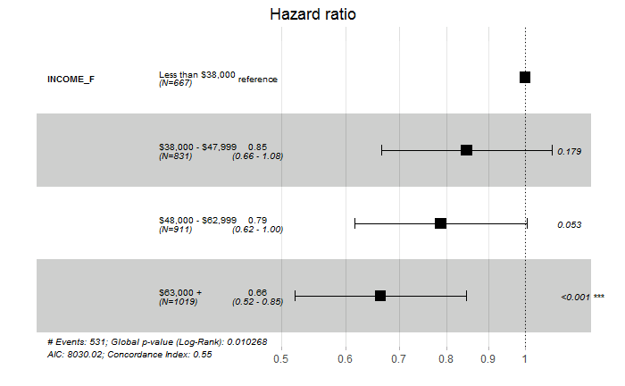

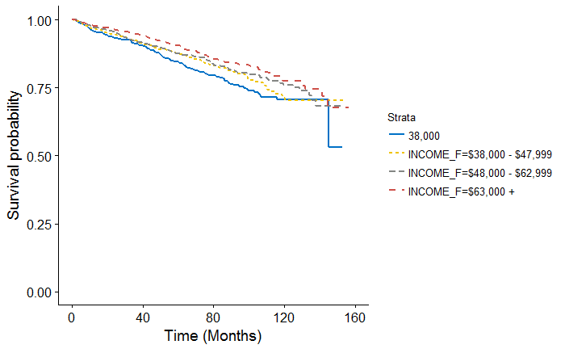

```r
uni_var(test_var = "INCOME_F", data_imp = data)
```

## Education

```
_________________________________________________

## EDUCATION_F
_________________________________________________
Call: survfit(formula = Surv(DX_LASTCONTACT_DEATH_MONTHS, PUF_VITAL_STATUS ==
    0) ~ EDUCATION_F, data = data)

   27 observations deleted due to missingness
                            n events median 0.95LCL 0.95UCL
EDUCATION_F=21% or more   744    119     NA     145      NA
EDUCATION_F=13 - 20.9%    931    137     NA      NA      NA
EDUCATION_F=7 - 12.9%    1032    167     NA      NA      NA
EDUCATION_F=Less than 7%  723    109     NA      NA      NA

Call: survfit(formula = Surv(DX_LASTCONTACT_DEATH_MONTHS, PUF_VITAL_STATUS ==
    0) ~ EDUCATION_F, data = data)

27 observations deleted due to missingness
                EDUCATION_F=21% or more
 time n.risk n.event survival std.err lower 95% CI upper 95% CI
   12    693      27    0.963 0.00699        0.949        0.977
   24    630      19    0.936 0.00913        0.918        0.954
   36    548      13    0.916 0.01054        0.895        0.937
   48    474      13    0.893 0.01206        0.869        0.917
   60    386      13    0.866 0.01376        0.840        0.894
  120     68      33    0.738 0.02534        0.690        0.789

                EDUCATION_F=13 - 20.9%
 time n.risk n.event survival std.err lower 95% CI upper 95% CI
   12    862      29    0.968 0.00581        0.957        0.980
   24    793      15    0.951 0.00722        0.937        0.965
   36    688      16    0.930 0.00869        0.914        0.948
   48    600      21    0.900 0.01061        0.880        0.921
   60    498      11    0.883 0.01166        0.860        0.906
  120     94      42    0.743 0.02416        0.697        0.792

                EDUCATION_F=7 - 12.9%
 time n.risk n.event survival std.err lower 95% CI upper 95% CI
   12    975      26    0.974 0.00495        0.965        0.984
   24    908      15    0.959 0.00626        0.947        0.971
```

[output cut: 27 more lines]

```
                            coef exp(coef) se(coef)      z Pr(>|z|)
EDUCATION_F13 - 20.9%   -0.11421   0.89207  0.12533 -0.911    0.362
EDUCATION_F7 - 12.9%    -0.04717   0.95393  0.11999 -0.393    0.694
EDUCATION_FLess than 7% -0.12187   0.88526  0.13265 -0.919    0.358

                        exp(coef) exp(-coef) lower .95 upper .95
EDUCATION_F13 - 20.9%      0.8921      1.121    0.6978     1.140
EDUCATION_F7 - 12.9%       0.9539      1.048    0.7540     1.207
EDUCATION_FLess than 7%    0.8853      1.130    0.6826     1.148

Concordance= 0.516  (se = 0.013 )
Rsquare= 0   (max possible= 0.904 )
Likelihood ratio test= 1.23  on 3 df,   p=0.747
Wald test            = 1.23  on 3 df,   p=0.7459
Score (logrank) test = 1.23  on 3 df,   p=0.7456
```

```
Removed 1 rows containing missing values (geom_errorbar).
```

```
## Unadjusted Kaplan Meier Overall Survival Curve for:  EDUCATION_F
```

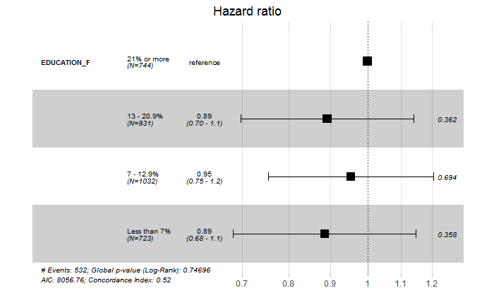

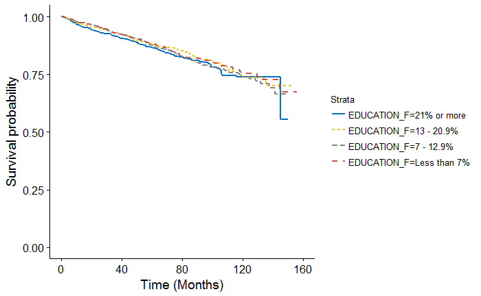

```r
uni_var(test_var = "EDUCATION_F", data_imp = data)
```

## Urban/Rural

```
_________________________________________________

## U_R_F
_________________________________________________
Call: survfit(formula = Surv(DX_LASTCONTACT_DEATH_MONTHS, PUF_VITAL_STATUS ==
    0) ~ U_R_F, data = data)

   130 observations deleted due to missingness
               n events median 0.95LCL 0.95UCL
U_R_F=Metro 2757    414     NA      NA      NA
U_R_F=Urban  502     84     NA     145      NA
U_R_F=Rural   68     17     NA     118      NA

Call: survfit(formula = Surv(DX_LASTCONTACT_DEATH_MONTHS, PUF_VITAL_STATUS ==
    0) ~ U_R_F, data = data)

130 observations deleted due to missingness
                U_R_F=Metro
 time n.risk n.event survival std.err lower 95% CI upper 95% CI
   12   2589      78    0.971 0.00322        0.965        0.978
   24   2401      44    0.954 0.00405        0.946        0.962
   36   2074      54    0.931 0.00500        0.922        0.941
   48   1778      54    0.905 0.00599        0.894        0.917
   60   1479      40    0.883 0.00678        0.870        0.897
  120    290     134    0.745 0.01348        0.719        0.772

                U_R_F=Urban
 time n.risk n.event survival std.err lower 95% CI upper 95% CI
   12    466      18    0.964 0.00844        0.947        0.980
   24    427      11    0.940 0.01076        0.919        0.962
   36    382      12    0.913 0.01308        0.887        0.939
   48    335       6    0.898 0.01422        0.870        0.926
   60    283      11    0.866 0.01665        0.834        0.899
  120     59      24    0.751 0.02846        0.697        0.809

                U_R_F=Rural
 time n.risk n.event survival std.err lower 95% CI upper 95% CI
   12     63       4    0.941  0.0286        0.886        0.999
   24     54       3    0.894  0.0378        0.823        0.972
   36     50       1    0.877  0.0408        0.801        0.961
```

[output cut: 17 more lines]

```
              coef exp(coef) se(coef)     z Pr(>|z|)
U_R_FUrban 0.07038   1.07292  0.11969 0.588   0.5565
U_R_FRural 0.50219   1.65233  0.24751 2.029   0.0425 *
---
Signif. codes:  0 *** 0.001 ** 0.01 * 0.05 . 0.1   1

           exp(coef) exp(-coef) lower .95 upper .95
U_R_FUrban     1.073     0.9320    0.8486     1.357
U_R_FRural     1.652     0.6052    1.0172     2.684

Concordance= 0.516  (se = 0.009 )
Rsquare= 0.001   (max possible= 0.903 )
Likelihood ratio test= 3.75  on 2 df,   p=0.1532
Wald test            = 4.3  on 2 df,   p=0.1167
Score (logrank) test = 4.38  on 2 df,   p=0.112
```

```
Removed 1 rows containing missing values (geom_errorbar).
```

```
## Unadjusted Kaplan Meier Overall Survival Curve for:  U_R_F
```

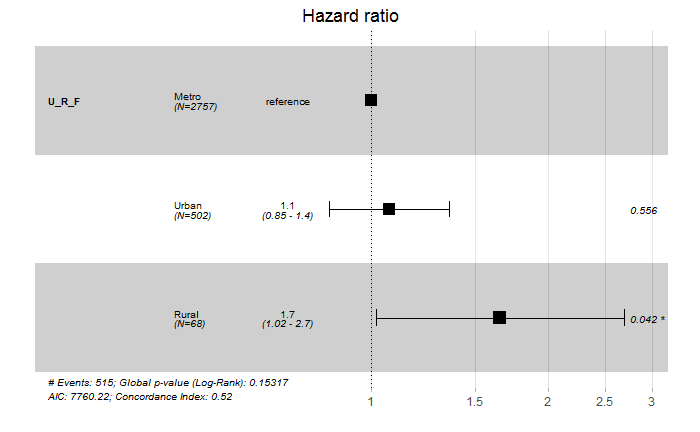

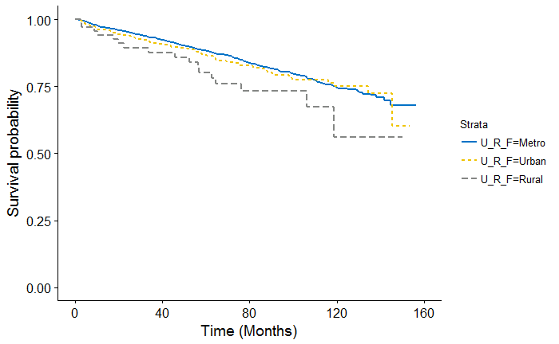

```r
uni_var(test_var = "U_R_F", data_imp = data)
```

## Comorbidities

```
_________________________________________________

## CDCC_TOTAL
_________________________________________________
Call: survfit(formula = Surv(DX_LASTCONTACT_DEATH_MONTHS, PUF_VITAL_STATUS ==
    0) ~ CDCC_TOTAL, data = data)

                n events median 0.95LCL 0.95UCL
CDCC_TOTAL=0 2743    390     NA      NA      NA
CDCC_TOTAL=1  567    107     NA     142      NA
CDCC_TOTAL=2  116     34    119     103      NA
CDCC_TOTAL=3   31      8     NA      NA      NA

Call: survfit(formula = Surv(DX_LASTCONTACT_DEATH_MONTHS, PUF_VITAL_STATUS ==
    0) ~ CDCC_TOTAL, data = data)

                CDCC_TOTAL=0
 time n.risk n.event survival std.err lower 95% CI upper 95% CI
   12   2582      70    0.974 0.00307        0.968        0.980
   24   2390      41    0.958 0.00389        0.951        0.966
   36   2089      51    0.937 0.00484        0.927        0.946
   48   1815      42    0.916 0.00565        0.905        0.927
   60   1519      45    0.892 0.00657        0.879        0.905
  120    314     131    0.762 0.01297        0.737        0.788

                CDCC_TOTAL=1
 time n.risk n.event survival std.err lower 95% CI upper 95% CI
   12    529      19    0.966 0.00772        0.951        0.981
   24    478      15    0.938 0.01033        0.918        0.958
   36    411      13    0.910 0.01254        0.886        0.935
   48    340      18    0.867 0.01553        0.837        0.898
   60    271      12    0.833 0.01776        0.799        0.869
  120     46      28    0.692 0.03028        0.636        0.754

                CDCC_TOTAL=2
 time n.risk n.event survival std.err lower 95% CI upper 95% CI
   12    102      11    0.904  0.0274        0.852        0.960
   24     92       4    0.868  0.0318        0.808        0.933
   36     75       6    0.807  0.0381        0.736        0.885
   48     63       5    0.751  0.0429        0.671        0.840
```

[output cut: 26 more lines]

```
CDCC_TOTAL2 0.9100    2.4843   0.1790 5.085 3.68e-07 ***
CDCC_TOTAL3 0.9719    2.6429   0.3575 2.718 0.006562 **
---
Signif. codes:  0 *** 0.001 ** 0.01 * 0.05 . 0.1   1

            exp(coef) exp(-coef) lower .95 upper .95
CDCC_TOTAL1     1.493     0.6699     1.205     1.849
CDCC_TOTAL2     2.484     0.4025     1.749     3.528
CDCC_TOTAL3     2.643     0.3784     1.311     5.326

Concordance= 0.555  (se = 0.009 )
Rsquare= 0.01   (max possible= 0.906 )
Likelihood ratio test= 34.45  on 3 df,   p=1.592e-07
Wald test            = 40.34  on 3 df,   p=9.014e-09
Score (logrank) test = 42.43  on 3 df,   p=3.249e-09
```

```
Removed 1 rows containing missing values (geom_errorbar).
```

```
## Unadjusted Kaplan Meier Overall Survival Curve for:  CDCC_TOTAL
```

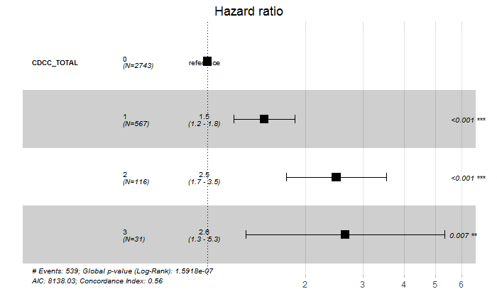

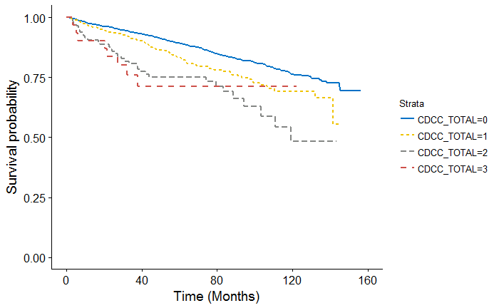

```r
uni_var(test_var = "CDCC_TOTAL", data_imp = data)
```